# Medijska zastupljenost redovničkih zajednica u hrvatskom digitalnom prostoru

Analiza ekonomije pažnje u medijskom izvještavanju o redovnicima i redovnicama

Author

DigiKat Project

Published

February 10, 2026

# Sažetak

Ovo istraživanje analizira kako hrvatski digitalni mediji prikazuju redovničke zajednice kroz teorijski okvir ekonomije pažnje. Koristeći DigiKat bazu digitalnog sadržaja od 2021. do 2025. godine, testiramo 9 hipoteza grupiranih u tri tematske cjeline koje pokrivaju koncentraciju pažnje, spolne razlike i tipologiju portala. Ključna pitanja su dobiva li mali broj redova većinu pažnje, postoje li rodne asimetrije u izvještavanju te razlikuju li se obrasci izvještavanja između mainstream, religijskih, regionalnih i lokalnih portala. Osim statističke značajnosti, izvještavamo veličine učinka (Gini koeficijent s bootstrap intervalima pouzdanosti, Cramérov V, rang biserijalna korelacija), primjenjujemo Benjamini Hochberg korekciju za višestruko testiranje te provodimo provjere robusnosti na alternativnim operacionalizacijama ključnih mjera.

**Ključne riječi** ekonomija pažnje, redovničke zajednice, medijska reprezentacija, digitalni mediji, Hrvatska

# 1 Uvod

## 1.1 Vidljivost i nevidljivost u digitalnom prostoru

Ekonomija pažnje je teorijski okvir koji polazi od činjenice da je informacija obilna, ali ljudska pažnja ograničena. Svaki dan možemo pročitati samo određen broj članaka i pogledati određen broj videa. To stvara konkurenciju za istu oskudnu pažnju publike.

Za redovničke zajednice ovo stvara specifičan paradoks. S jedne strane, medijska vidljivost pomaže u privlačenju novih zvanja, donacija i javne podrške. S druge strane, traženje medijske pozornosti može biti u suprotnosti s temeljnim vrijednostima poput poniznosti i kontemplacije. Ovaj paradoks nije jednako izražen kod svih redovničkih zajednica. Apostolski redovi, poput franjevaca, dominikanaca ili isusovaca, imaju dugu tradiciju javnog djelovanja kroz obrazovanje, znanstveni rad i propovijed, što ih čini prirodno vidljivijima u medijskom prostoru. Kontemplativni redovi, poput klarisa, karmelićanki ili benediktinki, organizirani su oko molitve i povlačenja iz javnog života, što ih čini strukturno nevidljivima za medijsku logiku koja favorizira javno djelovanje i događaje.

Ova razlika između apostolskih i kontemplativnih zajednica sugerira da medijska nevidljivost za neke redove nije slučajnost nego posljedica temeljnog nesklada između njihove karizme i logike medijske produkcije. Ako je to točno, ekonomija pažnje u kontekstu redovničkih zajednica ne odražava samo medijske preferencije nego i strukturne karakteristike samih zajednica.

## 1.2 Ekonomija pažnje kao teorijski okvir

Herbert Simon (1971) prvi je formulirao temeljnu tezu ekonomije pažnje tvrdnjom da bogatstvo informacija stvara siromaštvo pažnje. U kontekstu u kojem se količina dostupnih informacija eksponencijalno povećava, ljudska sposobnost da te informacije obradi ostaje biološki ograničena. Pažnja tako postaje oskudan resurs oko kojeg se odvija natjecanje među proizvođačima sadržaja.

Goldhaber (1997) je ovaj uvid proširio na digitalno okruženje tvrdeći da u mrežnom kontekstu pažnja funkcionira kao valuta. Svaki klik, dijeljenje ili komentiranje predstavlja alokaciju ograničenog resursa pažnje od strane korisnika. Davenport i Beck (2001) dodatno su razradili ovaj okvir identificirajući mehanizme kroz koje se pažnja privlači, mjeri i usmjerava u organizacijskom kontekstu. Njihov model sugerira da organizacije koje razumiju logiku ekonomije pažnje mogu strateški pozicionirati svoje poruke u informacijskom prostoru. Webster (2014) je pokazao kako se publika fragmentira u digitalnom okruženju, pri čemu se koncentracija pažnje paradoksalno povećava jer algoritamski sustavi preporučivanja pojačavaju već popularne sadržaje.

Za analizu medijske zastupljenosti redovničkih zajednica ovaj okvir nudi tri ključna predviđanja. Prvo, distribucija medijske pažnje neće biti ravnomjerna već će slijediti obrazac koncentracije u kojem mali broj aktera privlači nerazmjerno velik udio pozornosti. Ovo predviđanje proizlazi iz teorije kumulativne prednosti (Merton, 1968) prema kojoj se inicijalne razlike u vidljivosti pojačavaju jer mediji preferiraju izvještavati o akterima koji su već prepoznatljivi publici. Drugo, strukturne karakteristike aktera, poput spola i institucionalne veličine, utjecat će na raspodjelu pažnje jer medijski gatekeeperi donose uredničke odluke pod utjecajem postojećih društvenih hijerarhija. Treće, različiti tipovi medija raspodijelit će pažnju na različite načine jer operiraju prema različitim uredničkim logikama, ciljaju različite publike i imaju različite profesionalne norme.

Hjarvard (2008) uvodi pojam medijatizacije religije tvrdeći da mediji ne samo što prenose religijske sadržaje nego aktivno oblikuju način na koji se religija prakticira i razumije u suvremenom društvu. Lundby (2009) je pokazao da medijatizacija zahvaća sve aspekte religijske komunikacije, od institucionalnog predstavljanja do osobne duhovnosti. U kontekstu ekonomije pažnje ovo znači da medijska logika (koja favorizira konflikt, personalnu priču i institucionalnu krizu) može sustavno iskriviti javnu sliku redovničkih zajednica favorizirajući određene narative na račun drugih. Mediji mogu redovničke zajednice prikazivati primarno kroz prizmu skandala, imovine ili unutarnjih sukoba, marginalizirajući pritom svakodnevni život, karitativno djelovanje i duhovnu dimenziju zajednica. Wu (2016) je pokazao da ovaj mehanizam nije ograničen na religijski sadržaj nego je svojstven cijeloj digitalnoj ekonomiji pažnje u kojoj se sadržaj koji provocira emocionalnu reakciju sustavno pojačava.

Hoover (2006) je dokumentirao kako mediji postaju primarno mjesto na kojem suvremene publike konstruiraju razumijevanje religije, dok Campbell (2012) analizira specifičnu dinamiku online religijskih zajednica. Za redovničke zajednice ovo znači da je medijska reprezentacija postala centralno pitanje ne samo komunikacijske strategije nego i samog identiteta zajednice u javnom prostoru.

Kombinacijom ovih teorijskih uvida postavljamo 9 hipoteza grupiranih u tri bloka.

## 1.3 Hipoteze

### 1.3.1 Blok 1 Koncentracija pažnje

Teorija ekonomije pažnje predviđa neravnomjernu raspodjelu medijskog prostora. Ako se pažnja ponaša kao oskudan resurs, očekujemo da će distribucija medijskog prostora biti visoko koncentrirana, pri čemu mali broj redova i portala dominira ukupnom produkcijom sadržaja.

| Hipoteza | Tvrdnja | Test |
| --- | --- | --- |
| H1a | 20% redova dobiva preko 80% medijskog prostora | Gini > 0.60, Pareto omjer |
| H1b | 10 portala proizvodi preko 50% sadržaja | CR10, HHI indeks |
| H1c | Mali broj portala piše o malom broju redova | Udio top 5×5 > 30% |

### 1.3.2 Blok 2 Spolne razlike

Istražujemo dobivaju li muške zajednice više prostora od ženskih. Budući da su muški redovi institucionalno istaknuti i povijesno povezani s javnim djelovanjem (obrazovanjem, znanstvenim radom, javnom propovijedi), očekujemo da će medijska pažnja biti asimetrična u korist muških zajednica. Ova asimetrija mogla bi biti pojačana na portalima čija uređivačka logika favorizira institucionalni autoritet.

| Hipoteza | Tvrdnja | Test |
| --- | --- | --- |
| H2a | Muški redovi dobivaju preko 60% prostora | Chi square test, Cramérov V |
| H2b | Asimetrija izraženija na mainstream portalima | Test nezavisnosti, Cramérov V |
| H2c | Objave o muškim redovima generiraju više interakcija | Mann Whitney U test, rang biserijalna korelacija |

### 1.3.3 Blok 3 Tipologija portala

Različiti tipovi portala operiraju prema različitim uredničkim logikama. Mainstream nacionalni portali podliježu medijskoj logici koja favorizira konflikt i senzacionalizam, dok religijski portali imaju pastoralnu funkciju i ciljaju specifičnu publiku. Lokalni i regionalni portali fokusiraju se na događaje u zajednici i imaju drukčiji odnos prema redovničkim institucijama na svom području. Ove razlike u uredničkoj logici trebale bi se odraziti u tematskoj strukturi, sentimentu i dubini izvještavanja.

| Hipoteza | Tvrdnja | Test |
| --- | --- | --- |
| H3a | Mainstream portali češće pišu o kontroverzama | Chi square test, Cramérov V |
| H3b | Religijski portali imaju pozitivniji ton | Usporedba udjela, chi square |
| H3c | Religijski portali pišu duže članke | Mann Whitney test, Kruskal Wallis, rang biserijalna korelacija |

# 2 Podaci i metode

## 2.1 Izvor podataka

Koristimo DigiKat bazu koja sadrži objave s hrvatskih digitalnih medija prikupljene putem Determ platforme za praćenje medija. Determ je specijalizirani alat koji kontinuirano prikuplja i indeksira sadržaj s digitalnih medija na temelju unaprijed definiranih upita za pretraživanje. Baza pokriva razdoblje od 2021. do 2025. godine.

Za svaku objavu baza sadrži naslov, puni tekst, datum objave, naziv izvora (portala), tip izvora i broj interakcija. **Varijabla INTERACTIONS bilježi ukupan zbroj korisničkih angažmana s pojedinom objavom, uključujući reakcije, komentare i dijeljenja na platformama na kojima je sadržaj distribuiran.** Budući da se radi o agregiranoj mjeri, jedna viralna objava može generirati nerazmjerno velik broj interakcija. Ovu karakteristiku varijable uzimamo u obzir u interpretaciji rezultata.

## 2.2 Identifikacija sadržaja o redovničkim zajednicama

Iz ukupnog korpusa identificirali smo objave relevantne za redovničke zajednice korištenjem opsežnog rječnika ključnih riječi. Rječnik obuhvaća specifične pojmove za 30+ redovničkih zajednica (npr. franjevac, dominikanac, isusovac, kapucin, benediktinac, salezijanac, karmelićanin za muške te franjevka, dominikanka, benediktinka, uršulinka, milosrdnica za ženske zajednice), kao i generičke pojmove (redovnik, redovnica, časna sestra, pater).

Za svaku objavu pretraživali smo naslov, puni tekst i isječak spominjanja. Objava je uključena u analitički korpus ako sadrži barem jednu od ključnih riječi. Pretraživanje je provedeno korištenjem vektoriziranih operacija (`stri_detect_fixed` iz paketa `stringi`) radi računalne efikasnosti.

## 2.3 Klasifikacija po redovničkim zajednicama

Važno je razumjeti logiku klasifikacije generičkih pojmova. Ako tekst sadrži i specifičan pojam (npr. franjevac) i generički pojam (npr. redovnik), objava se klasificira prema specifičnom pojmu jer sustav provjerava specifične pojmove prije generičkih. Kategorije “Generički muški redovnik” i “Generička redovnica” obuhvaćaju isključivo objave u kojima novinar koristi samo generički pojam bez navođenja konkretnog reda. Ovo je analitički relevantno jer upućuje na praksu medijskog izvještavanja u kojem se redovnička pripadnost ne specificira.

Klasificirane zajednice grupirane su u obitelji redova (franjevačka, dominikanska, isusovačka, benediktinska, salezijanska, karmelska) te prema spolu (muški, ženski).

## 2.4 Klasifikacija portala

Portale smo klasificirali u četiri kategorije. **Mainstream nacionalni portali** obuhvaćaju velike informativne portale s nacionalnom publikom (index.hr, vecernji.hr, jutarnji.hr, 24sata.hr, net.hr, telegram.hr, nacional.hr, dnevnik.hr, rtl.hr, n1info.hr). **Religijski katolički portali** obuhvaćaju portale specijalizirane za religijske teme (ika.hr, bitno.net, katolicki.hr, laudato.hr, veritas.hr). **Regionalni portali** definirani su kao portali koji pokrivaju područje jedne ili više županija. **Lokalni portali** obuhvaćaju portale fokusirane na pojedini grad ili općinu.

## 2.5 Identifikacija kontroverznog sadržaja

Za testiranje hipoteze H3a o razlikama u tematskoj strukturi, osim automatiziranog sentimenta koristimo i eksplicitni indikator kontroverznog sadržaja. Kontroverznim smo označili objave koje u naslovu ili tekstu sadrže barem jednu od sljedećih ključnih riječi: skandal, zlostavljanje, istraga, optužba, tužba, kaznena, sud, presuda, imovina, financij, pronevjera, korupcija, sukob, spor. Ova mjera je konzervativna jer pokriva samo eksplicitno kontroverzne teme, ali je pouzdanija od čistog sentimenta kao proxyja za kontroverznost.

## 2.6 Kriteriji rangiranja

Kada u analizi govorimo o top 5 ili top 10 redova, kriterij je ukupan broj interakcija (zbroj svih angažmana korisnika s objavama o tom redu uključujući reakcije, komentare i dijeljenja). Odabrali smo interakcije umjesto pukog broja objava jer interakcije bolje odražavaju koliko medijske pažnje publika stvarno alocira na pojedinu temu, što je u skladu s teorijskim okvirom ekonomije pažnje. Za rangiranje portala koristimo broj objava jer je to mjera produkcijskog kapaciteta pojedinog portala. Budući da je distribucija interakcija ekstremno zakrivljena (nekoliko viralnih objava može dominirati ukupnim interakcijama za pojedini red), provjeravamo i koliki udio ukupnih interakcija generira top 1% najuspješnijih objava.

## 2.7 Statističke metode

Za mjerenje koncentracije primjenjujemo Gini koeficijent, Lorenzovu krivulju, koncentracijske omjere (CR5, CR10) i HHI indeks. Za Gini koeficijent izvještavamo bootstrap intervale pouzdanosti (2000 replikacija, percentilna metoda) jer standardne asimptotske formule nisu pouzdane za male uzorke redova. Za testiranje razlika u proporcijama koristimo chi square test i test proporcija. Za testiranje razlika u distribucijama koristimo Mann Whitney U test jer distribucije interakcija i duljina tekstova tipično nisu normalne. Za usporedbu više od dviju grupa koristimo Kruskal Wallis test s Dunnovim post hoc parnim usporedbama.

Osim p vrijednosti, za svaki test izvještavamo odgovarajuću mjeru veličine učinka. Za chi square testove izvještavamo Cramérov V (mali učinak V < 0.10, srednji 0.10 do 0.30, veliki > 0.30). Za Mann Whitney testove izvještavamo rang biserijalnu korelaciju (mali učinak r < 0.10, srednji 0.10 do 0.30, veliki > 0.30). Za mjere koncentracije interpretiramo apsolutne vrijednosti Gini koeficijenta i HHI indeksa.

Budući da testiramo 9 hipoteza na istom korpusu, u završnoj tablici primjenjujemo Benjamini Hochberg korekciju za višestruko testiranje (False Discovery Rate kontrola na razini 0.05). Ovo osigurava da ukupna stopa lažnih pozitivnih nalaza ostaje pod kontrolom.

Za hipotezu H2c o razlikama u angažmanu koristimo dvije mjere pažnje: ukupne interakcije po objavi i stopu angažmana (medijan interakcija). Stopa angažmana normalizira za razliku u broju objava između muških i ženskih redova.

**Prikaži kod**

```r
franciscan_male <- list(
  ofm = list(
    name = "Franjevci (OFM)",
    family = "Franciscan Family",
    keywords = c(
      "franjevac", "franjevci", "franjevački", "franjevačka", "franjevačko",
      "mala braća", "red manje braće",
      "provincija sv. ćirila i metoda", "provincija presvetog otkupitelja",
      "hrvatska franjevačka provincija", "franjevačka provincija",
      "franjevački samostan", "franjevačka crkva"
    )
  ),
  ofmconv = list(
    name = "Franjevci konventualci (OFMConv)",
    family = "Franciscan Family",
    keywords = c(
      "franjevci konventualci", "franjevac konventualac",
      "konventualci", "konventualac", "crni franjevci"
    )
  ),
  ofmcap = list(
    name = "Kapucini (OFMCap)",
    family = "Franciscan Family",
    keywords = c(
      "kapucin", "kapucini", "kapucinski",
      "kapucinska provincija", "kapucinski samostan"
    )
  ),
  tor = list(
    name = "Franjevci trećoredci (TOR)",
    family = "Franciscan Family",
    keywords = c(
      "trećoredci", "trećoredac", "trecoredci",
      "franjevci trećoredci glagoljaši"
    )
  )
)

dominican_male <- list(
  op = list(
    name = "Dominikanci (OP)",
    family = "Dominican Family",
    keywords = c(
      "dominikanac", "dominikanci", "dominikanski",
      "red propovjednika", "propovjednici",
      "dominikanski samostan", "dominikanska crkva"
    )
  )
)

jesuit <- list(
  sj = list(
    name = "Isusovci (SJ)",
    family = "Jesuit",
    keywords = c(
      "isusovac", "isusovci", "isusovački",
      "družba isusova", "societas iesu",
      "isusovačka crkva", "isusovački kolegij"
    )
  )
)

benedictine_male <- list(
  osb = list(
    name = "Benediktinci (OSB)",
    family = "Benedictine Family",
    keywords = c(
      "benediktinac", "benediktinci", "benediktinski",
      "benediktinska opatija", "benediktinski samostan"
    )
  ),
  ocist = list(
    name = "Cisterciti (OCist)",
    family = "Benedictine Family",
    keywords = c("cistercit", "cisterciti", "cistercitski")
  )
)

carmelite_male <- list(
  ocarm = list(
    name = "Karmelićani (OCarm)",
    family = "Carmelite Family",
    keywords = c(
      "karmelićanin", "karmelićani", "karmelski",
      "karmelićanski samostan"
    )
  ),
  ocd = list(
    name = "Karmelićani bosonogi (OCD)",
    family = "Carmelite Family",
    keywords = c("karmelićani bosonogi", "bosonogi karmelićani")
  )
)

salesian_male <- list(
  sdb = list(
    name = "Salezijanci (SDB)",
    family = "Salesian Family",
    keywords = c(
      "salezijanac", "salezijanci", "salezijanski",
      "don bosco", "salezijanski centar",
      "salezijanska škola", "salezijanski dom"
    )
  )
)

pauline <- list(
  osppe = list(
    name = "Pavlini (OSPPE)",
    family = "Other Male Orders",
    keywords = c("pavlin", "pavlini", "pavlinski", "red sv. pavla pustinjaka")
  )
)

missionary_male <- list(
  cssp = list(
    name = "Spiritanci (CSSp)",
    family = "Other Male Orders",
    keywords = c("spiritanac", "spiritanci", "spiritanski", "misionari duha svetoga")
  ),
  svd = list(
    name = "Verbiti (SVD)",
    family = "Other Male Orders",
    keywords = c("verbit", "verbiti", "verbitski", "družba božje riječi")
  ),
  scj = list(
    name = "Dehonijanci (SCJ)",
    family = "Other Male Orders",
    keywords = c("dehonijanac", "dehonijanci", "dehonijanski")
  ),
  smm = list(
    name = "Monfortanci (SMM)",
    family = "Other Male Orders",
    keywords = c("monfortanac", "monfortanci", "monfortanski")
  ),
  cpps = list(
    name = "Misionari Krvi Kristove (CPPS)",
    family = "Other Male Orders",
    keywords = c("misionar krvi kristove", "misionari krvi kristove")
  ),
  sac = list(
    name = "Palotinci (SAC)",
    family = "Other Male Orders",
    keywords = c("palotinac", "palotinci", "palotinski")
  )
)

other_male <- list(
  osa = list(
    name = "Augustinci (OSA)",
    family = "Other Male Orders",
    keywords = c("augustinac", "augustinci", "augustinski")
  ),
  cm = list(
    name = "Lazaristi (CM)",
    family = "Other Male Orders",
    keywords = c("lazarist", "lazaristi", "misijska družba", "vincentinci")
  ),
  cssr = list(
    name = "Redemptoristi (CSsR)",
    family = "Other Male Orders",
    keywords = c("redemptorist", "redemptoristi")
  )
)

franciscan_female <- list(
  osf_generic = list(
    name = "Franjevke (općenito)",
    family = "Franciscan Family",
    keywords = c(
      "franjevka", "franjevke", "sestre franjevke", "franjevačke sestre"
    )
  ),
  ossf = list(
    name = "Školske sestre franjevke",
    family = "Franciscan Family",
    keywords = c("školske sestre franjevke", "školska sestra franjevka")
  )
)

dominican_female <- list(
  op_f = list(
    name = "Dominikanke (OP)",
    family = "Dominican Family",
    keywords = c(
      "dominikanka", "dominikanke", "sestre dominikanke", "dominikanske sestre"
    )
  )
)

benedictine_female <- list(
  osb_f = list(
    name = "Benediktinke (OSB)",
    family = "Benedictine Family",
    keywords = c(
      "benediktinka", "benediktinke", "opatica", "benediktinski samostan"
    )
  )
)

carmelite_female <- list(
  ocd_f = list(
    name = "Karmelićanke (OCD)",
    family = "Carmelite Family",
    keywords = c(
      "karmelićanka", "karmelićanke", "sestre karmelićanke",
      "karmel", "karmelski samostan"
    )
  )
)

poor_clares <- list(
  osc = list(
    name = "Klarise (OSC)",
    family = "Franciscan Family",
    keywords = c("klarisa", "klarise", "sestre klarise", "red svete klare")
  )
)

ursulines <- list(
  osu = list(
    name = "Uršulinke (OSU)",
    family = "Congregations of Women",
    keywords = c("uršulinka", "uršulinke", "sestre uršulinke", "uršulinska škola")
  )
)

sisters_charity <- list(
  dc = list(
    name = "Milosrdnice (DC)",
    family = "Congregations of Women",
    keywords = c(
      "milosrdnica", "milosrdnice", "milosrdna sestra",
      "sestre milosrdnice", "kćeri kršćanske ljubavi"
    )
  )
)

daughters_love <- list(
  fdl = list(
    name = "Kćeri Božje Ljubavi",
    family = "Congregations of Women",
    keywords = c("kćeri božje ljubavi", "kćer božje ljubavi")
  )
)

adorers <- list(
  asc = list(
    name = "Klanjateljice Krvi Kristove",
    family = "Congregations of Women",
    keywords = c("klanjateljice krvi kristove", "klanjateljica krvi kristove")
  )
)

salesian_female <- list(
  fma = list(
    name = "Kćeri Marije Pomoćnice (FMA)",
    family = "Salesian Family",
    keywords = c(
      "kćeri marije pomoćnice", "salezijanke", "salezijanka", "sestre don bosca"
    )
  )
)

sacred_heart <- list(
  sscj = list(
    name = "Sestre Presvetog Srca Isusova",
    family = "Congregations of Women",
    keywords = c("sestre presvetog srca isusova")
  ),
  fcj = list(
    name = "Kćeri Srca Isusova",
    family = "Congregations of Women",
    keywords = c("kćeri srca isusova")
  )
)

marian_sisters <- list(
  olvm = list(
    name = "Marijine sestre čudotvorne medaljice",
    family = "Congregations of Women",
    keywords = c("marijine sestre čudotvorne medaljice")
  ),
  vhm = list(
    name = "Sestre pohoda Marijina",
    family = "Congregations of Women",
    keywords = c("sestre pohoda marijina", "vizitantke")
  )
)

servants <- list(
  sij = list(
    name = "Služavke malog Isusa",
    family = "Congregations of Women",
    keywords = c("služavke malog isusa")
  ),
  ancelle = list(
    name = "Ančele",
    family = "Congregations of Women",
    keywords = c("ančele", "ančela", "ancele")
  )
)

missionaries_charity <- list(
  mc = list(
    name = "Misionarke ljubavi",
    family = "Congregations of Women",
    keywords = c("misionarke ljubavi", "majka terezija", "sestre majke terezije")
  )
)

merciful_jesus <- list(
  smj = list(
    name = "Sestre Milosrdnog Isusa",
    family = "Congregations of Women",
    keywords = c("sestre milosrdnog isusa")
  )
)

greek_catholic <- list(
  osbm = list(
    name = "Bazilijanke (OSBM)",
    family = "Other Female Orders",
    keywords = c("bazilijanka", "bazilijanke", "vasilijanka", "vasilijanke")
  )
)

generic_terms <- list(
  male_generic = list(
    keywords = c("redovnik", "redovnici", "pater", "otac")
  ),
  female_generic = list(
    keywords = c("redovnica", "redovnice", "časna", "časna sestra", "sestra")
  ),
  institutional = list(
    keywords = c("provincija", "kustodija", "družba", "samostan", "opatija",
                 "provincijalat", "generalni poglavar", "provincijal")
  )
)
```

**Prikaži kod**

```r
extract_keywords <- function(order_list) {
  keywords <- c()
  for (order in order_list) {
    if (!is.null(order$keywords)) {
      keywords <- c(keywords, order$keywords)
    }
  }
  return(keywords)
}

male_order_keywords <- c(
  extract_keywords(franciscan_male),
  extract_keywords(dominican_male),
  extract_keywords(jesuit),
  extract_keywords(benedictine_male),
  extract_keywords(carmelite_male),
  extract_keywords(salesian_male),
  extract_keywords(pauline),
  extract_keywords(missionary_male),
  extract_keywords(other_male)
)

female_order_keywords <- c(
  extract_keywords(franciscan_female),
  extract_keywords(dominican_female),
  extract_keywords(benedictine_female),
  extract_keywords(carmelite_female),
  extract_keywords(poor_clares),
  extract_keywords(ursulines),
  extract_keywords(sisters_charity),
  extract_keywords(daughters_love),
  extract_keywords(adorers),
  extract_keywords(salesian_female),
  extract_keywords(sacred_heart),
  extract_keywords(marian_sisters),
  extract_keywords(servants),
  extract_keywords(missionaries_charity),
  extract_keywords(merciful_jesus),
  extract_keywords(greek_catholic)
)

generic_keywords <- c(
  generic_terms$male_generic$keywords,
  generic_terms$female_generic$keywords,
  generic_terms$institutional$keywords
)

all_order_keywords <- unique(c(
  male_order_keywords,
  female_order_keywords,
  generic_keywords
))

all_order_keywords_clean <- gsub("\\\\b", "", all_order_keywords)
simple_keywords <- tolower(all_order_keywords_clean)
simple_keywords <- simple_keywords[nchar(simple_keywords) > 2]
```

**Prikaži kod**

```r
## NOTE: In production, replace the heuristic below with a manually curated
## lookup table of the top 50 portals by volume. Run:
##   dta[, .N, by = FROM][order(-N)] %>% head(50)
## and assign each portal manually. The heuristic below serves as a fallback.

classify_portal_type <- function(source_name) {
  source_lower <- tolower(source_name)

  mainstream_national <- c(
    "index.hr", "vecernji.hr", "jutarnji.hr", "24sata.hr", "net.hr",
    "telegram.hr", "nacional.hr", "dnevnik.hr", "rtl.hr", "n1info.hr",
    "tportal.hr", "hrt.hr"
  )

  religious_catholic <- c(
    "ika.hr", "bitno.net", "katolicki.hr", "laudato.hr", "veritas.hr",
    "catholic.hr", "crkva.hr", "nadbiskupija", "biskupija", "zupa",
    "katolicki-tjednik", "svetoduh"
  )

  regional <- c(
    "slobodnadalmacija.hr", "novilist.hr", "glas-slavonije.hr",
    "glasistre.hr", "zadarskilist.hr", "dubrovackidnevnik.hr",
    "dalmacijadanas.hr", "dalmatinskiportal.hr", "057info.hr",
    "sibenik.in", "morski.hr", "regional.hr", "regionalexpress.hr",
    "034portal.hr", "sjeverozapad.hr", "epodravina.hr", "evarazdin.hr",
    "regionalni.com", "prigorski.hr"
  )

  local <- c(
    "zadar.hr", "zagreb.info", "split.com.hr", "rijeka.hr",
    "osijek.hr", "pula.hr", "dubrovnik.hr", "karlovac.hr",
    "sisak.hr", "varazdin.hr", "koprivnica.hr", "bjelovar.hr",
    "virovitica.hr", "pozega.hr", "slavonskibrod.hr", "vukovar.hr",
    "gospic.hr", "zabok.hr", "samobor.hr", "zapresic.hr",
    "velika-gorica.hr", "dugo-selo.hr"
  )

  if (any(sapply(mainstream_national, function(x) grepl(x, source_lower, fixed = TRUE)))) {
    return("Mainstream National")
  }
  if (any(sapply(religious_catholic, function(x) grepl(x, source_lower, fixed = TRUE)))) {
    return("Religious Catholic")
  }
  if (any(sapply(regional, function(x) grepl(x, source_lower, fixed = TRUE)))) {
    return("Regional")
  }
  if (any(sapply(local, function(x) grepl(x, source_lower, fixed = TRUE)))) {
    return("Local")
  }
  return("Local")
}
```

**Prikaži kod**

```r
dta_full <- readRDS("C:/Users/lsikic/Luka C/HKS/Projekti/Digitalni Kat/SHKM/DigiKat/data/merged_comprehensive.rds")

setDT(dta_full)

if (is.character(dta_full$DATE)) {
  dta_full[, DATE := as.Date(DATE)]
}
if (!"year" %in% names(dta_full)) {
  dta_full[, year := year(DATE)]
}
if (!"month" %in% names(dta_full)) {
  dta_full[, month := month(DATE)]
}

dta_full <- dta_full[SOURCE_TYPE == "web"]
dta_full <- dta_full[DATE >= as.Date("2021-01-01") & DATE <= as.Date("2025-12-31")]
dta_full <- dta_full[year >= 2021 & year <= 2025]

cat("Učitana DigiKat baza podataka\n")
```

```
Učitana DigiKat baza podataka
```

**Prikaži kod**

```r
cat("Ukupno objava:", format(nrow(dta_full), big.mark = ","), "\n")
```

```
Ukupno objava: 447,908
```

**Prikaži kod**

```r
## Vectorized keyword filtering using stringi (much faster than row-wise sapply)
dta_full[, text_lower := tolower(paste(
  fifelse(is.na(TITLE), "", TITLE),
  fifelse(is.na(FULL_TEXT), "", FULL_TEXT),
  fifelse(is.na(MENTION_SNIPPET), "", MENTION_SNIPPET)
))]

cat("Filtriranje sadržaja o redovničkim zajednicama (vektorizirano)\n")
```

```
Filtriranje sadržaja o redovničkim zajednicama (vektorizirano)
```

**Prikaži kod**

```r
## Build a single logical vector using stri_detect_fixed across all keywords
hit_matrix <- sapply(simple_keywords, function(kw) {
  stri_detect_fixed(dta_full$text_lower, kw)
})
dta_full[, has_order_content := rowSums(hit_matrix) > 0]

dta <- dta_full[has_order_content == TRUE]

if (is.character(dta$DATE)) {
  dta[, DATE := as.Date(DATE)]
}
if (!"year" %in% names(dta)) {
  dta[, year := year(DATE)]
}
if (!"month" %in% names(dta)) {
  dta[, month := month(DATE)]
}

dta_full[, text_lower := NULL]
dta_full[, has_order_content := NULL]

cat("\nFiltriranje završeno\n")
```

```
Filtriranje završeno
```

**Prikaži kod**

```r
cat("Objave o redovničkim zajednicama:", format(nrow(dta), big.mark = ","), "\n")
```

```
Objave o redovničkim zajednicama: 125,842
```

**Prikaži kod**

```r
cat("Postotak ukupnog korpusa:", sprintf("%.2f%%", nrow(dta) / nrow(dta_full) * 100), "\n")
```

```
Postotak ukupnog korpusa: 28.10%
```

**Prikaži kod**

```r
classify_religious_order <- function(text) {
  if (is.na(text) || text == "") return(list(order = "Unknown", family = "Unknown", gender = "Unknown"))

  text_lower <- tolower(text)

  ## Use word boundary aware matching for "fra" to avoid false positives
  if (any(sapply(c("franjevac", "franjevci", "\\bfra\\b", "mala braća"),
                 function(k) grepl(k, text_lower, perl = TRUE)))) {
    if (grepl("konventual", text_lower)) {
      return(list(order = "Franjevci konventualci", family = "Franciscan Family", gender = "Male"))
    }
    if (!grepl("franjevk", text_lower)) {
      return(list(order = "Franjevci OFM", family = "Franciscan Family", gender = "Male"))
    }
  }

  if (grepl("kapucin", text_lower)) {
    return(list(order = "Kapucini", family = "Franciscan Family", gender = "Male"))
  }

  if (grepl("dominikanac|dominikanci", text_lower) && !grepl("dominikank", text_lower)) {
    return(list(order = "Dominikanci", family = "Dominican Family", gender = "Male"))
  }

  if (grepl("isusovac|isusovci|družba isusova", text_lower)) {
    return(list(order = "Isusovci", family = "Jesuit", gender = "Male"))
  }

  if (grepl("benediktinac|benediktinci", text_lower) && !grepl("benediktink", text_lower)) {
    return(list(order = "Benediktinci", family = "Benedictine Family", gender = "Male"))
  }

  if (grepl("salezijanac|salezijanci", text_lower) && !grepl("salezijank", text_lower)) {
    return(list(order = "Salezijanci", family = "Salesian Family", gender = "Male"))
  }

  if (grepl("karmelićanin|karmelićani", text_lower) && !grepl("karmelićank", text_lower)) {
    return(list(order = "Karmelićani", family = "Carmelite Family", gender = "Male"))
  }

  if (grepl("pavlin", text_lower)) {
    return(list(order = "Pavlini", family = "Other Male Orders", gender = "Male"))
  }
  if (grepl("spiritan", text_lower)) {
    return(list(order = "Spiritanci", family = "Other Male Orders", gender = "Male"))
  }
  if (grepl("verbit", text_lower)) {
    return(list(order = "Verbiti", family = "Other Male Orders", gender = "Male"))
  }
  if (grepl("dehonijan", text_lower)) {
    return(list(order = "Dehonijanci", family = "Other Male Orders", gender = "Male"))
  }

  if (grepl("franjevk", text_lower)) {
    return(list(order = "Franjevke", family = "Franciscan Family", gender = "Female"))
  }
  if (grepl("klaris", text_lower)) {
    return(list(order = "Klarise", family = "Franciscan Family", gender = "Female"))
  }
  if (grepl("dominikank", text_lower)) {
    return(list(order = "Dominikanke", family = "Dominican Family", gender = "Female"))
  }
  if (grepl("benediktink|opatica", text_lower)) {
    return(list(order = "Benediktinke", family = "Benedictine Family", gender = "Female"))
  }
  if (grepl("karmelićank", text_lower)) {
    return(list(order = "Karmelićanke", family = "Carmelite Family", gender = "Female"))
  }
  if (grepl("uršulink", text_lower)) {
    return(list(order = "Uršulinke", family = "Congregations of Women", gender = "Female"))
  }
  if (grepl("milosrdnic|milosrdna sestra", text_lower)) {
    return(list(order = "Milosrdnice", family = "Congregations of Women", gender = "Female"))
  }
  if (grepl("kćeri marije pomoćnice|salezijank", text_lower)) {
    return(list(order = "Kćeri Marije Pomoćnice", family = "Salesian Family", gender = "Female"))
  }
  if (grepl("kćeri božje ljubavi", text_lower)) {
    return(list(order = "Kćeri Božje Ljubavi", family = "Congregations of Women", gender = "Female"))
  }
  if (grepl("klanjateljice", text_lower)) {
    return(list(order = "Klanjateljice Krvi Kristove", family = "Congregations of Women", gender = "Female"))
  }
  if (grepl("misionarke ljubavi|majka terezija", text_lower)) {
    return(list(order = "Misionarke ljubavi", family = "Congregations of Women", gender = "Female"))
  }
  if (grepl("bazilijank|vasilijank", text_lower)) {
    return(list(order = "Bazilijanke", family = "Other Female Orders", gender = "Female"))
  }

  ## Generic terms: only reached if no specific order matched above
  if (grepl("\\bredovnik|\\bredovnici|\\bpater\\b|\\botac\\b", text_lower, perl = TRUE) &&
      !grepl("\\bredovnic", text_lower, perl = TRUE)) {
    return(list(order = "Generički muški redovnik", family = "Unknown", gender = "Male"))
  }
  if (grepl("\\bredovnic|\\bčasna\\b|\\bsestra\\b", text_lower, perl = TRUE)) {
    return(list(order = "Generička redovnica", family = "Unknown", gender = "Female"))
  }

  return(list(order = "Unknown", family = "Unknown", gender = "Unknown"))
}

cat("Klasifikacija objava po redovničkim zajednicama\n")
```

```
Klasifikacija objava po redovničkim zajednicama
```

**Prikaži kod**

```r
dta[, text_combined := tolower(paste(
  fifelse(is.na(TITLE), "", TITLE),
  fifelse(is.na(FULL_TEXT), "", FULL_TEXT)
))]

classification_results <- lapply(dta$text_combined, classify_religious_order)

dta[, ORDER := sapply(classification_results, function(x) x$order)]
dta[, ORDER_FAMILY := sapply(classification_results, function(x) x$family)]
dta[, GENDER := sapply(classification_results, function(x) x$gender)]

dta[, text_combined := NULL]
cat("Klasifikacija završena\n")
```

```
Klasifikacija završena
```

**Prikaži kod**

```r
cat("Klasifikacija portala po tipu\n")
```

```
Klasifikacija portala po tipu
```

**Prikaži kod**

```r
portal_classifications <- unique(dta[, .(FROM)])
portal_classifications[, PORTAL_TYPE := sapply(FROM, classify_portal_type)]

dta <- merge(dta, portal_classifications, by = "FROM", all.x = TRUE)

portal_summary <- dta[, .N, by = PORTAL_TYPE][order(-N)]
print(portal_summary)
```

```
           PORTAL_TYPE     N
                <char> <int>
1:               Local 92132
2: Mainstream National 13953
3:            Regional 11472
4:  Religious Catholic  8285
```

**Prikaži kod**

```r
cat("\nKlasifikacija portala završena\n")
```

```
Klasifikacija portala završena
```

**Prikaži kod**

```r
## Text length and word count
dta[, TEXT_LENGTH := nchar(FULL_TEXT)]
dta[, WORD_COUNT := sapply(strsplit(as.character(FULL_TEXT), "\\s+"), length)]
dta[is.na(FULL_TEXT), WORD_COUNT := 0L]

## Engagement rate: interactions per post (for per-order comparisons)
## This normalizes for volume differences between orders
dta[, ENGAGEMENT_RATE := fifelse(is.na(INTERACTIONS), 0, INTERACTIONS)]

## Controversy indicator based on explicit keywords
controversy_keywords <- c(
  "skandal", "zlostavljanje", "istraga", "optužba", "tužba",
  "kaznena", "\\bsud\\b", "presuda", "imovina", "financij",
  "pronevjera", "korupcija", "sukob", "\\bspor\\b"
)

dta[, text_for_controversy := tolower(paste(
  fifelse(is.na(TITLE), "", TITLE),
  fifelse(is.na(FULL_TEXT), "", FULL_TEXT)
))]

dta[, IS_CONTROVERSY := sapply(text_for_controversy, function(t) {
  any(sapply(controversy_keywords, function(k) grepl(k, t, perl = TRUE)))
})]

dta[, text_for_controversy := NULL]

cat("Kontroverzne objave:", format(sum(dta$IS_CONTROVERSY), big.mark = ","),
    sprintf("(%.1f%%)", mean(dta$IS_CONTROVERSY) * 100), "\n")
```

```
Kontroverzne objave: 23,668 (18.8%)
```

## 2.8 Pregled korpusa

**Prikaži kod**

```r
n_posts <- nrow(dta)
n_sources <- uniqueN(dta$FROM)
date_min <- min(dta$DATE, na.rm = TRUE)
date_max <- max(dta$DATE, na.rm = TRUE)

tibble(
  Metrika = c(
    "Ukupno objava o redovnicima",
    "Jedinstvenih izvora",
    "Vremenski raspon",
    "Platforma",
    "Godine",
    "Objave o muškim redovnicima",
    "Objave o ženskim redovnicama",
    "Mainstream portali",
    "Religijski portali",
    "Regionalni portali",
    "Lokalni portali"
  ),
  Vrijednost = c(
    format(n_posts, big.mark = ","),
    format(n_sources, big.mark = ","),
    paste(date_min, "do", date_max),
    "web",
    paste(sort(unique(year(dta$DATE))), collapse = ", "),
    format(sum(dta$GENDER == "Male", na.rm = TRUE), big.mark = ","),
    format(sum(dta$GENDER == "Female", na.rm = TRUE), big.mark = ","),
    format(sum(dta$PORTAL_TYPE == "Mainstream National", na.rm = TRUE), big.mark = ","),
    format(sum(dta$PORTAL_TYPE == "Religious Catholic", na.rm = TRUE), big.mark = ","),
    format(sum(dta$PORTAL_TYPE == "Regional", na.rm = TRUE), big.mark = ","),
    format(sum(dta$PORTAL_TYPE == "Local", na.rm = TRUE), big.mark = ",")
  )
) %>%
  kable(col.names = c("Metrika", "Vrijednost"),
        caption = "Pregled korpusa") %>%
  kable_styling(bootstrap_options = c("striped", "hover"), full_width = FALSE)
```

Pregled korpusa

| Metrika | Vrijednost |
| --- | --- |
| Ukupno objava o redovnicima | 125,842 |
| Jedinstvenih izvora | 1,734 |
| Vremenski raspon | 2021-01-01 do 2025-12-31 |
| Platforma | web |
| Godine | 2021, 2022, 2023, 2024, 2025 |
| Objave o muškim redovnicima | 77,142 |
| Objave o ženskim redovnicama | 24,344 |
| Mainstream portali | 13,953 |
| Religijski portali | 8,285 |
| Regionalni portali | 11,472 |
| Lokalni portali | 92,132 |

### 2.8.1 Kvaliteta podataka

Prije analitičkih postupaka provjeravamo kompletnost ključnih varijabli.

**Prikaži kod**

```r
## Missing data audit
quality_vars <- c("TITLE", "FULL_TEXT", "DATE", "FROM", "INTERACTIONS",
                  "AUTO_SENTIMENT", "SOURCE_TYPE")

quality_df <- tibble(
  Varijabla = quality_vars,
  `Ukupno zapisa` = nrow(dta),
  `Nedostaje (N)` = sapply(quality_vars, function(v) {
    if (v %in% names(dta)) sum(is.na(dta[[v]]) | dta[[v]] == "") else NA
  }),
  `Nedostaje (%)` = sapply(quality_vars, function(v) {
    if (v %in% names(dta)) sprintf("%.1f%%", mean(is.na(dta[[v]]) | dta[[v]] == "") * 100) else "N/A"
  }),
  `Nulte vrijednosti` = sapply(quality_vars, function(v) {
    if (v %in% names(dta) && is.numeric(dta[[v]])) {
      format(sum(dta[[v]] == 0, na.rm = TRUE), big.mark = ",")
    } else ""
  })
)

quality_df %>%
  kable(caption = "Kompletnost ključnih varijabli") %>%
  kable_styling(bootstrap_options = c("striped", "hover"), full_width = FALSE)
```

Kompletnost ključnih varijabli

| Varijabla | Ukupno zapisa | Nedostaje (N) | Nedostaje (%) | Nulte vrijednosti |
| --- | --- | --- | --- | --- |
| TITLE | 125842 | 59 | 0.0% |  |
| FULL_TEXT | 125842 | 0 | 0.0% |  |
| DATE | 125842 | NA | NA% |  |
| FROM | 125842 | 0 | 0.0% |  |
| INTERACTIONS | 125842 | 4 | 0.0% | 54,396 |
| AUTO_SENTIMENT | 125842 | 0 | 0.0% |  |
| SOURCE_TYPE | 125842 | 0 | 0.0% |  |

**Prikaži kod**

```r
## Flag: articles with zero-length text
n_empty_text <- sum(is.na(dta$FULL_TEXT) | nchar(dta$FULL_TEXT) < 10, na.rm = TRUE)
pct_empty_text <- n_empty_text / nrow(dta) * 100
cat(sprintf("Objave s praznim ili iznimno kratkim tekstom (<10 znakova): %s (%.1f%%)\n",
            format(n_empty_text, big.mark = ","), pct_empty_text))
```

```
Objave s praznim ili iznimno kratkim tekstom (<10 znakova): 0 (0.0%)
```

**Prikaži kod**

```r
## Articles with zero interactions (may be legitimate or missing)
n_zero_int <- sum(dta$INTERACTIONS == 0 | is.na(dta$INTERACTIONS))
pct_zero_int <- n_zero_int / nrow(dta) * 100
cat(sprintf("Objave s 0 ili nedostajućih interakcija: %s (%.1f%%)\n",
            format(n_zero_int, big.mark = ","), pct_zero_int))
```

```
Objave s 0 ili nedostajućih interakcija: 54,400 (43.2%)
```

### 2.8.2 Validacija klasifikatora

**Prikaži kod**

```r
## Draw a reproducible random sample for validation
set.seed(42)
n_sample <- min(200, nrow(dta))
validation_idx <- sample(nrow(dta), n_sample)
validation_sample <- dta[validation_idx]

## For each sampled article, check if the assigned ORDER appears in the text
## This is a proxy validation: we check whether the classified order's keywords
## actually appear in the text (keyword presence validation)
validation_sample[, text_check := tolower(paste(
  fifelse(is.na(TITLE), "", TITLE),
  fifelse(is.na(FULL_TEXT), "", FULL_TEXT)
))]

## Check generic false positives: for articles classified as generic,
## verify whether a specific order keyword was actually missed
check_generic_fp <- function(text, order_assigned) {
  if (!order_assigned %in% c("Generički muški redovnik", "Generička redovnica")) {
    return("specific")
  }
  ## Check if any specific order keyword appears in the text
  specific_kws <- c("franjevac", "franjevci", "dominikanac", "dominikanci",
                     "isusovac", "isusovci", "benediktinac", "benediktinci",
                     "kapucin", "salezijanac", "salezijanci",
                     "franjevk", "dominikank", "benediktink", "uršulink",
                     "milosrdnic", "klaris", "karmelićan")
  has_specific <- any(sapply(specific_kws, function(k) grepl(k, text, fixed = TRUE)))
  if (has_specific) return("false_generic")  ## Should have been classified specifically
  return("true_generic")                     ## Correctly generic
}

validation_sample[, generic_check := mapply(check_generic_fp, text_check, ORDER)]

## Check potential false positives for "sestra" (most problematic keyword)
sestra_articles <- dta[ORDER == "Generička redovnica"]
set.seed(123)
sestra_sample_idx <- sample(nrow(sestra_articles), min(100, nrow(sestra_articles)))
sestra_sample <- sestra_articles[sestra_sample_idx]

## Heuristic check: if text contains "sestra" but also contains common
## non-religious uses (medicinska sestra, sestra po majci, etc.)
sestra_sample[, text_check := tolower(paste(
  fifelse(is.na(TITLE), "", TITLE),
  fifelse(is.na(FULL_TEXT), "", FULL_TEXT)
))]

sestra_sample[, has_religious_context := sapply(text_check, function(t) {
  any(sapply(c("samostan", "red", "zajednica", "crkv", "molitv", "bogoslov",
               "provincial", "habit", "zavjet", "klauzur", "liturgi"),
             function(k) grepl(k, t, fixed = TRUE)))
})]

n_generic <- sum(validation_sample$generic_check == "true_generic")
n_false_generic <- sum(validation_sample$generic_check == "false_generic")
n_specific <- sum(validation_sample$generic_check == "specific")
n_sestra_religious <- sum(sestra_sample$has_religious_context)
n_sestra_total <- nrow(sestra_sample)

validation_sample[, text_check := NULL]
sestra_sample[, text_check := NULL]

tibble(
  Provjera = c(
    "Uzorak za validaciju",
    "Objave s prepoznatim specifičnim redom",
    "Objave korektno klasificirane kao generičke",
    "Objave pogrešno klasificirane kao generičke (propušten specifičan red)",
    "Uzorak generičkih redovnica",
    "Od toga s eksplicitnim religijskim kontekstom",
    "Procijenjeni udio lažnih pozitiva (generička redovnica)"
  ),
  Vrijednost = c(
    format(n_sample, big.mark = ","),
    format(n_specific, big.mark = ","),
    format(n_generic, big.mark = ","),
    format(n_false_generic, big.mark = ","),
    format(n_sestra_total, big.mark = ","),
    format(n_sestra_religious, big.mark = ","),
    sprintf("%.1f%%", (1 - n_sestra_religious / n_sestra_total) * 100)
  )
) %>%
  kable(caption = "Validacija klasifikatora") %>%
  kable_styling(bootstrap_options = c("striped", "hover"), full_width = FALSE)
```

Validacija klasifikatora

| Provjera | Vrijednost |
| --- | --- |
| Uzorak za validaciju | 200 |
| Objave s prepoznatim specifičnim redom | 119 |
| Objave korektno klasificirane kao generičke | 80 |
| Objave pogrešno klasificirane kao generičke (propušten specifičan red) | 1 |
| Uzorak generičkih redovnica | 100 |
| Od toga s eksplicitnim religijskim kontekstom | 95 |
| Procijenjeni udio lažnih pozitiva (generička redovnica) | 5.0% |

### 2.8.3 Generička klasifikacija i lažni pozitivi

Analitički je relevantno koliko objava sadrži samo generičke pojmove (redovnik, redovnica, časna sestra) bez navođenja konkretnog reda. Posebnu pozornost zaslužuje pojam “sestra” koji se u hrvatskom jeziku koristi i izvan religijskog konteksta (medicinska sestra, sestra po krvi).

**Prikaži kod**

```r
generic_summary <- dta[ORDER %in% c("Generički muški redovnik", "Generička redovnica"), .(
  Posts = .N
), by = ORDER]
generic_summary[, Share := Posts / nrow(dta) * 100]

specific_posts <- nrow(dta[!ORDER %in% c("Generički muški redovnik", "Generička redovnica", "Unknown")])
generic_posts <- sum(generic_summary$Posts)

tibble(
  Kategorija = c(generic_summary$ORDER, "Ukupno generičkih", "Objave s identificiranim redom"),
  `Broj objava` = c(
    format(generic_summary$Posts, big.mark = ","),
    format(generic_posts, big.mark = ","),
    format(specific_posts, big.mark = ",")
  ),
  `Udio u korpusu` = c(
    sprintf("%.1f%%", generic_summary$Share),
    sprintf("%.1f%%", generic_posts / nrow(dta) * 100),
    sprintf("%.1f%%", specific_posts / nrow(dta) * 100)
  )
) %>%
  kable(caption = "Objave s generičkim vs specifičnim identifikatorom reda") %>%
  kable_styling(bootstrap_options = c("striped", "hover"), full_width = FALSE)
```

Objave s generičkim vs specifičnim identifikatorom reda

| Kategorija | Broj objava | Udio u korpusu |
| --- | --- | --- |
| Generički muški redovnik | 35,482 | 28.2% |
| Generička redovnica | 17,124 | 13.6% |
| Ukupno generičkih | 52,606 | 41.8% |
| Objave s identificiranim redom | 48,880 | 38.8% |

### 2.8.4 Provjera viralnosti interakcija

Budući da koristimo interakcije kao mjeru pažnje, važno je provjeriti koliki udio ukupnih interakcija dolazi od malog broja viralnih objava.

**Prikaži kod**

```r
interaction_data <- dta[!is.na(INTERACTIONS) & INTERACTIONS > 0]
total_int <- sum(interaction_data$INTERACTIONS)

## Top 1% articles by interactions
top1pct_n <- ceiling(nrow(interaction_data) * 0.01)
setorder(interaction_data, -INTERACTIONS)
top1pct_int <- sum(interaction_data[1:top1pct_n, INTERACTIONS])
top1pct_share <- top1pct_int / total_int * 100

## Top 5% articles
top5pct_n <- ceiling(nrow(interaction_data) * 0.05)
top5pct_int <- sum(interaction_data[1:top5pct_n, INTERACTIONS])
top5pct_share <- top5pct_int / total_int * 100

tibble(
  Metrika = c(
    "Objave s barem 1 interakcijom",
    "Top 1% objava (udio interakcija)",
    "Top 5% objava (udio interakcija)",
    "Medijan interakcija",
    "Prosjek interakcija",
    "Maksimum interakcija"
  ),
  Vrijednost = c(
    format(nrow(interaction_data), big.mark = ","),
    sprintf("%.1f%% (%s objava)", top1pct_share, format(top1pct_n, big.mark = ",")),
    sprintf("%.1f%% (%s objava)", top5pct_share, format(top5pct_n, big.mark = ",")),
    format(median(interaction_data$INTERACTIONS), big.mark = ","),
    format(round(mean(interaction_data$INTERACTIONS)), big.mark = ","),
    format(max(interaction_data$INTERACTIONS), big.mark = ",")
  )
) %>%
  kable(caption = "Distribucija interakcija i utjecaj viralnih objava") %>%
  kable_styling(bootstrap_options = c("striped", "hover"), full_width = FALSE)
```

Distribucija interakcija i utjecaj viralnih objava

| Metrika | Vrijednost |
| --- | --- |
| Objave s barem 1 interakcijom | 71,442 |
| Top 1% objava (udio interakcija) | 33.1% (715 objava) |
| Top 5% objava (udio interakcija) | 60.7% (3,573 objava) |
| Medijan interakcija | 36 |
| Prosjek interakcija | 191 |
| Maksimum interakcija | 79,394 |

Top 10 objava po interakcijama, s naznakom reda i portala:

**Prikaži kod**

```r
top_viral <- interaction_data[1:min(10, nrow(interaction_data)),
                              .(FROM, ORDER, ORDER_FAMILY, GENDER,
                                DATE, INTERACTIONS, IS_CONTROVERSY)]

top_viral[, .(
  Portal = FROM,
  Red = ORDER,
  Datum = as.character(DATE),
  Interakcije = format(INTERACTIONS, big.mark = ","),
  Kontroverza = ifelse(IS_CONTROVERSY, "Da", "Ne")
)] %>%
  kable(caption = "Top 10 viralnih objava o redovničkim zajednicama") %>%
  kable_styling(bootstrap_options = c("striped", "hover"), full_width = FALSE,
                font_size = 11)
```

Top 10 viralnih objava o redovničkim zajednicama

| Portal | Red | Datum | Interakcije | Kontroverza |
| --- | --- | --- | --- | --- |
| gov.hr | Generički muški redovnik | 2025-06-04 | 79,394 | Da |
| rtl.hr | Unknown | 2022-04-29 | 72,070 | Da |
| vecernji.hr | Benediktinci | 2021-08-28 | 48,272 | Ne |
| vecernji.hr | Generički muški redovnik | 2022-03-22 | 48,242 | Ne |
| dnevno.hr | Generička redovnica | 2021-04-18 | 37,002 | Ne |
| dnevno.hr | Generička redovnica | 2023-07-02 | 36,958 | Da |
| dnevno.hr | Generička redovnica | 2021-10-17 | 36,944 | Da |
| dnevno.hr | Generički muški redovnik | 2021-10-23 | 36,944 | Da |
| dnevno.hr | Generički muški redovnik | 2022-11-14 | 36,944 | Ne |
| dnevno.hr | Generička redovnica | 2022-01-22 | 36,944 | Ne |

### 2.8.5 Distribucija po obiteljima redova

**Prikaži kod**

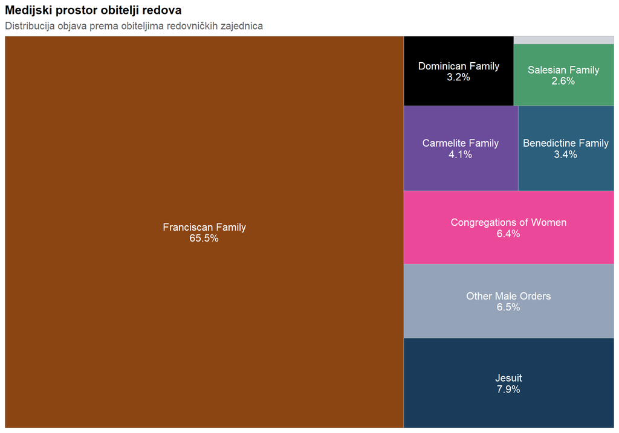

Figure 1: Treemap obitelji redova po broju objava

```r
family_summary <- dta[ORDER_FAMILY != "Unknown", .(
  Posts = .N,
  Total_Interactions = sum(INTERACTIONS, na.rm = TRUE)
), by = ORDER_FAMILY][order(-Posts)]
family_summary[, Share := Posts / sum(Posts) * 100]

ggplot(family_summary, aes(area = Posts, fill = ORDER_FAMILY,
       label = paste0(ORDER_FAMILY, "\n", sprintf("%.1f%%", Share)))) +
  geom_treemap() +
  geom_treemap_text(color = "white", place = "centre", size = 12) +
  scale_fill_manual(values = order_family_colors, guide = "none") +
  labs(
    title = "Medijski prostor obitelji redova",
    subtitle = "Distribucija objava prema obiteljima redovničkih zajednica"
  )
```

### 2.8.6 Distribucija objava po tipu portala

**Prikaži kod**

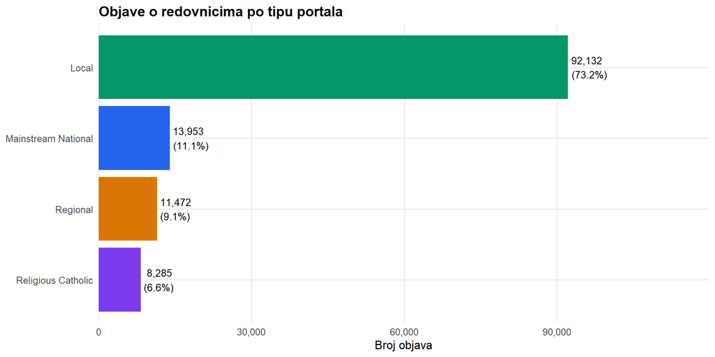

Figure 2: Distribucija objava po tipu portala

```r
portal_dist <- dta[, .(Posts = .N), by = PORTAL_TYPE][order(-Posts)]
portal_dist[, Share := Posts / sum(Posts) * 100]

ggplot(portal_dist, aes(x = reorder(PORTAL_TYPE, Posts), y = Posts, fill = PORTAL_TYPE)) +
  geom_col() +
  geom_text(aes(label = paste0(format(Posts, big.mark = ","), "\n(", sprintf("%.1f%%", Share), ")")),
            hjust = -0.1, size = 3.5) +
  coord_flip() +
  scale_fill_manual(values = portal_type_colors, guide = "none") +
  scale_y_continuous(labels = comma, expand = expansion(mult = c(0, 0.3))) +
  labs(
    title = "Objave o redovnicima po tipu portala",
    x = NULL,
    y = "Broj objava"
  )
```

### 2.8.7 Raznolikost portala po redu

Koje redove pokriva širok spektar portala, a koji su vidljivi samo na jednom tipu? Shannon indeks raznolikosti portala za svaki red mjeri koliko je ravnomjerno raspoređena pokrivenost reda po različitim portalima. Viši indeks znači da red privlači pažnju šireg spektra medija.

**Prikaži kod**

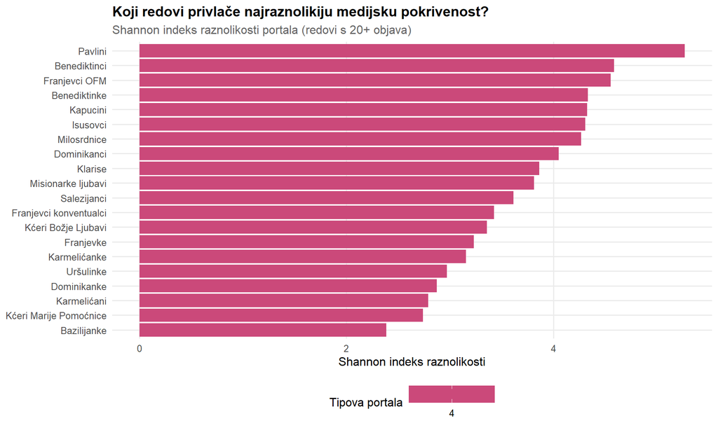

Raznolikost portala po redu (Shannon indeks)

```r
## Shannon diversity: how many different portals cover each order
order_portal_diversity <- dta[ORDER != "Unknown" & ORDER != "Generički muški redovnik" &
                              ORDER != "Generička redovnica",
                              .(N_portals = uniqueN(FROM),
                                N_posts = .N,
                                N_portal_types = uniqueN(PORTAL_TYPE)), by = ORDER]

## Shannon entropy of portal distribution per order
shannon_per_order <- dta[ORDER != "Unknown" & ORDER != "Generički muški redovnik" &
                         ORDER != "Generička redovnica",
                         {
                           portal_counts <- .SD[, .N, by = FROM]
                           p <- portal_counts$N / sum(portal_counts$N)
                           .(Shannon = -sum(p * log(p)),
                             N_portals = uniqueN(FROM),
                             N_posts = .N,
                             N_portal_types = uniqueN(PORTAL_TYPE))
                         }, by = ORDER]

## Only show orders with at least 20 articles for meaningful diversity
shannon_plot <- shannon_per_order[N_posts >= 20][order(-Shannon)]

ggplot(shannon_plot[1:min(20, nrow(shannon_plot))],
       aes(x = reorder(ORDER, Shannon), y = Shannon, fill = N_portal_types)) +
  geom_col() +
  coord_flip() +
  scale_fill_viridis_c(option = "plasma", name = "Tipova portala") +
  labs(
    title = "Koji redovi privlače najraznolikiju medijsku pokrivenost?",
    subtitle = "Shannon indeks raznolikosti portala (redovi s 20+ objava)",
    x = NULL,
    y = "Shannon indeks raznolikosti"
  )
```

**Prikaži kod**

```r
shannon_plot[1:min(10, nrow(shannon_plot)), .(
  Red = ORDER,
  Objave = format(N_posts, big.mark = ","),
  `Različitih portala` = N_portals,
  `Tipova portala` = N_portal_types,
  Shannon = sprintf("%.2f", Shannon)
)] %>%
  kable(caption = "Top 10 redova po raznolikosti medijske pokrivenosti") %>%
  kable_styling(bootstrap_options = c("striped", "hover"), full_width = FALSE)
```

Top 10 redova po raznolikosti medijske pokrivenosti

| Red | Objave | Različitih portala | Tipova portala | Shannon |
| --- | --- | --- | --- | --- |
| Pavlini | 3,109 | 507 | 4 | 5.27 |
| Benediktinci | 856 | 230 | 4 | 4.58 |
| Franjevci OFM | 26,717 | 786 | 4 | 4.55 |
| Benediktinke | 814 | 197 | 4 | 4.33 |
| Kapucini | 1,327 | 219 | 4 | 4.32 |
| Isusovci | 3,862 | 385 | 4 | 4.31 |
| Milosrdnice | 1,867 | 279 | 4 | 4.27 |
| Dominikanci | 1,294 | 229 | 4 | 4.05 |
| Klarise | 417 | 114 | 4 | 3.86 |
| Misionarke ljubavi | 465 | 130 | 4 | 3.81 |

### 2.8.8 Supojavljivanje redova

Članci ponekad spominju više od jednog reda, primjerice kada se uspoređuju zajednice ili izvještava o zajedničkim projektima. Provjeravamo koliko je česta supojavljivost različitih redova u istom tekstu.

**Prikaži kod**

```r
## For each article, check how many different specific order keywords appear
specific_orders <- c("franjevac", "franjevci", "dominikanac", "dominikanci",
                     "isusovac", "isusovci", "benediktinac", "benediktinci",
                     "kapucin", "salezijanac", "salezijanci",
                     "franjevk", "dominikank", "benediktink", "uršulink",
                     "milosrdnic", "klaris", "karmelićan")

dta[, text_for_comention := tolower(paste(
  fifelse(is.na(TITLE), "", TITLE),
  fifelse(is.na(FULL_TEXT), "", FULL_TEXT)
))]

dta[, n_orders_mentioned := sapply(text_for_comention, function(t) {
  sum(sapply(specific_orders, function(k) grepl(k, t, fixed = TRUE)))
})]

dta[, text_for_comention := NULL]

comention_summary <- dta[, .(
  `Broj objava` = .N,
  Udio = sprintf("%.1f%%", .N / nrow(dta) * 100)
), by = .(Redova = fifelse(n_orders_mentioned >= 3, "3+", as.character(n_orders_mentioned)))]
setorder(comention_summary, Redova)

comention_summary %>%
  kable(caption = "Koliko objava spominje više od jednog reda?") %>%
  kable_styling(bootstrap_options = c("striped", "hover"), full_width = FALSE)
```

Koliko objava spominje više od jednog reda?

| Redova | Broj objava | Udio |
| --- | --- | --- |
| 0 | 93881 | 74.6% |
| 1 | 25019 | 19.9% |
| 2 | 5680 | 4.5% |
| 3+ | 1262 | 1.0% |

5.5% objava spominje dva ili više redova, što potvrđuje da je klasifikacija po jednom redu opravdana za veliku većinu objava.

# 3 Rezultati

## 3.1 Blok 1 Koncentracija pažnje

### 3.1.1 H1a Koncentracija među redovničkim zajednicama

Testiramo predviđanje da 20% redova dobiva preko 80% medijskog prostora. Rangiranje redova temelji se na ukupnom broju interakcija.

**Prikaži kod**

```r
order_attention <- dta[ORDER != "Unknown", .(
  Posts = .N,
  Total_Interactions = sum(INTERACTIONS, na.rm = TRUE)
), by = ORDER][order(-Total_Interactions)]

order_attention[, Rank := .I]
total_interactions <- sum(order_attention$Total_Interactions)
order_attention[, Cumulative_Interactions := cumsum(Total_Interactions) / total_interactions * 100]
order_attention[, Cumulative_Orders := .I / .N * 100]

gini_orders <- Gini(order_attention$Total_Interactions)

## Bootstrap CI for Gini
gini_boot <- boot_gini(order_attention$Total_Interactions)

n_orders <- nrow(order_attention)
top_20pct <- ceiling(n_orders * 0.20)
pareto_share <- sum(order_attention[1:top_20pct, Total_Interactions]) / total_interactions * 100

cr5 <- sum(order_attention[1:min(5, n_orders), Total_Interactions]) / total_interactions * 100
cr10 <- sum(order_attention[1:min(10, n_orders), Total_Interactions]) / total_interactions * 100

log_model <- lm(log(Total_Interactions) ~ log(Rank), data = order_attention[Total_Interactions > 0])
r_squared <- summary(log_model)$r.squared

## Also compute Gini based on post counts as robustness
gini_orders_posts <- Gini(order_attention$Posts)
gini_boot_posts <- boot_gini(order_attention$Posts)
```

**Prikaži kod**

```r
tibble(
  Metrika = c(
    "Gini koeficijent (interakcije)",
    "95% CI za Gini (bootstrap)",
    "Gini koeficijent (broj objava)",
    "95% CI za Gini objava (bootstrap)",
    "Top 20% redova (udio pažnje)",
    "Top 5 redova (udio pažnje)",
    "Top 10 redova (udio pažnje)",
    "Power Law R²",
    "Ukupno identificiranih redova"
  ),
  Vrijednost = c(
    sprintf("%.3f", gini_orders),
    sprintf("[%.3f, %.3f]", gini_boot$lower, gini_boot$upper),
    sprintf("%.3f", gini_orders_posts),
    sprintf("[%.3f, %.3f]", gini_boot_posts$lower, gini_boot_posts$upper),
    sprintf("%.1f%%", pareto_share),
    sprintf("%.1f%%", cr5),
    sprintf("%.1f%%", cr10),
    sprintf("%.3f", r_squared),
    format(n_orders, big.mark = ",")
  ),
  Prag = c("> 0.60", "", "> 0.60", "", "> 80%", "", "", "> 0.80", ""),
  Rezultat = c(
    ifelse(gini_orders > 0.60, "✓ Podržana", "✗ Nije podržana"),
    "",
    ifelse(gini_orders_posts > 0.60, "✓ Konzistentno", "✗ Nekonzistentno"),
    "",
    ifelse(pareto_share > 80, "✓ Podržana", "✗ Nije podržana"),
    "", "",
    ifelse(r_squared > 0.80, "✓ Power law", ""),
    ""
  )
) %>%
  kable(caption = "H1a Koncentracija među redovničkim zajednicama",
        align = c("l", "r", "c", "l")) %>%
  kable_styling(bootstrap_options = c("striped", "hover"), full_width = FALSE)
```

H1a Koncentracija među redovničkim zajednicama

| Metrika | Vrijednost | Prag | Rezultat |
| --- | --- | --- | --- |
| Gini koeficijent (interakcije) | 0.820 | > 0.60 | ✓ Podržana |
| 95% CI za Gini (bootstrap) | [0.534, 0.855] |  |  |
| Gini koeficijent (broj objava) | 0.784 | > 0.60 | ✓ Konzistentno |
| 95% CI za Gini objava (bootstrap) | [0.526, 0.821] |  |  |
| Top 20% redova (udio pažnje) | 90.4% | > 80% | ✓ Podržana |
| Top 5 redova (udio pažnje) | 88.8% |  |  |
| Top 10 redova (udio pažnje) | 95.1% |  |  |
| Power Law R² | 0.866 | > 0.80 | ✓ Power law |
| Ukupno identificiranih redova | 26 |  |  |

Kompletna rang lista svih identificiranih redova:

**Prikaži kod**

```r
order_attention[, .(
  Rang = Rank,
  Red = ORDER,
  Objave = format(Posts, big.mark = ","),
  Interakcije = format(Total_Interactions, big.mark = ","),
  `Prosj. inter./objava` = sprintf("%.1f", Total_Interactions / Posts),
  `Kum. udio inter.` = sprintf("%.1f%%", Cumulative_Interactions)
)] %>%
  kable(caption = "Kompletna rang lista redova po ukupnim interakcijama") %>%
  kable_styling(bootstrap_options = c("striped", "hover"), full_width = FALSE,
                font_size = 11) %>%
  scroll_box(height = "400px")
```

Kompletna rang lista redova po ukupnim interakcijama

| Rang | Red | Objave | Interakcije | Prosj. inter./objava | Kum. udio inter. |
| --- | --- | --- | --- | --- | --- |
| 1 | Generički muški redovnik | 35,482 | 5,097,326 | 143.7 | 43.5% |
| 2 | Franjevci OFM | 26,717 | 2,757,827 | 103.2 | 67.1% |
| 3 | Generička redovnica | 17,124 | 1,867,848 | 109.1 | 83.1% |
| 4 | Isusovci | 3,862 | 439,324 | 113.8 | 86.8% |
| 5 | Franjevci konventualci | 2,531 | 230,351 | 91.0 | 88.8% |
| 6 | Milosrdnice | 1,867 | 193,390 | 103.6 | 90.4% |
| 7 | Pavlini | 3,109 | 191,135 | 61.5 | 92.1% |
| 8 | Dominikanci | 1,294 | 126,065 | 97.4 | 93.2% |
| 9 | Kapucini | 1,327 | 111,626 | 84.1 | 94.1% |
| 10 | Salezijanci | 1,204 | 110,911 | 92.1 | 95.1% |
| 11 | Benediktinci | 856 | 103,627 | 121.1 | 95.9% |
| 12 | Karmelićanke | 1,323 | 78,561 | 59.4 | 96.6% |
| 13 | Benediktinke | 814 | 64,456 | 79.2 | 97.2% |
| 14 | Franjevke | 1,026 | 63,857 | 62.2 | 97.7% |
| 15 | Misionarke ljubavi | 465 | 60,285 | 129.6 | 98.2% |
| 16 | Klarise | 417 | 56,422 | 135.3 | 98.7% |
| 17 | Karmelićani | 671 | 48,739 | 72.6 | 99.1% |
| 18 | Kćeri Božje Ljubavi | 434 | 40,727 | 93.8 | 99.5% |
| 19 | Uršulinke | 234 | 21,789 | 93.1 | 99.7% |
| 20 | Klanjateljice Krvi Kristove | 149 | 10,926 | 73.3 | 99.7% |
| 21 | Verbiti | 35 | 10,555 | 301.6 | 99.8% |
| 22 | Dominikanke | 269 | 9,579 | 35.6 | 99.9% |
| 23 | Bazilijanke | 157 | 3,355 | 21.4 | 99.9% |
| 24 | Kćeri Marije Pomoćnice | 65 | 3,270 | 50.3 | 100.0% |
| 25 | Dehonijanci | 32 | 1,348 | 42.1 | 100.0% |
| 26 | Spiritanci | 22 | 1,268 | 57.6 | 100.0% |

**Prikaži kod**

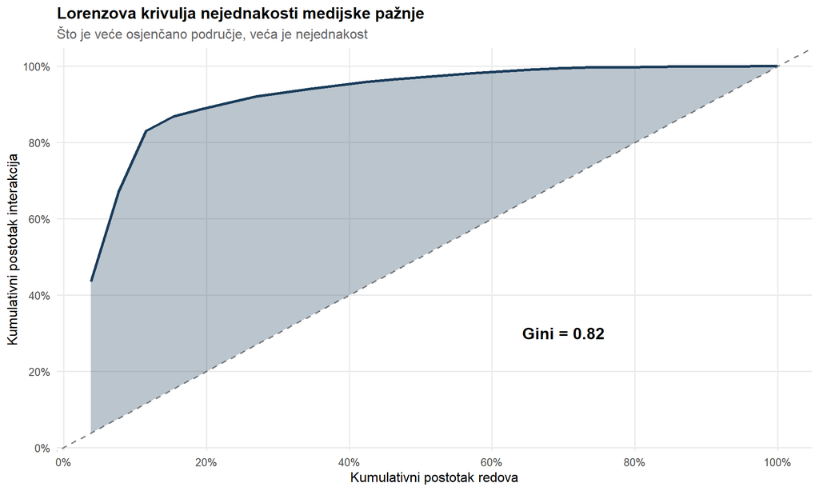

Figure 3: Lorenzova krivulja nejednakosti pažnje među redovničkim zajednicama

```r
ggplot(order_attention, aes(x = Cumulative_Orders, y = Cumulative_Interactions)) +
  geom_line(color = "#1a3c5a", linewidth = 1.2) +
  geom_abline(intercept = 0, slope = 1, linetype = "dashed", color = "gray50") +
  geom_ribbon(aes(ymin = Cumulative_Orders, ymax = Cumulative_Interactions),
              fill = "#1a3c5a", alpha = 0.3) +
  annotate("text", x = 70, y = 30,
           label = paste0("Gini = ", round(gini_orders, 3)),
           size = 5, fontface = "bold") +
  scale_x_continuous(labels = function(x) paste0(x, "%"), breaks = seq(0, 100, 20)) +
  scale_y_continuous(labels = function(x) paste0(x, "%"), breaks = seq(0, 100, 20)) +
  labs(
    title = "Lorenzova krivulja nejednakosti medijske pažnje",
    subtitle = "Što je veće osjenčano područje, veća je nejednakost",
    x = "Kumulativni postotak redova",
    y = "Kumulativni postotak interakcija"
  )
```

Gini koeficijent od 0.820 (95% CI [0.534, 0.855]) prelazi prag od 0.60. Ovaj nalaz je robustan jer i Gini koeficijent temeljen na broju objava (0.784) pokazuje jednako visoku koncentraciju. Top 20% redova dobiva 90.4% pažnje, što potvrđuje Paretov princip. Tablica s potpunom rang listom otkriva i koliko prosječnih interakcija svaki red generira po objavi, čime se djelomično kontrolira utjecaj volumena. **H1a je podržana**.

### 3.1.2 H1b Koncentracija među portalima

Testiramo predviđanje da 10 portala proizvodi preko 50% sadržaja o redovnicima.

**Prikaži kod**

```r
portal_attention <- dta[, .(
  Posts = .N,
  Total_Interactions = sum(INTERACTIONS, na.rm = TRUE)
), by = FROM][order(-Posts)]

portal_attention[, Rank := .I]
total_posts <- sum(portal_attention$Posts)

cr10_portals <- sum(portal_attention[1:10, Posts]) / total_posts * 100
hhi <- sum((portal_attention$Posts / total_posts * 100)^2)
gini_portals <- Gini(portal_attention$Posts)
```

**Prikaži kod**

```r
tibble(
  Metrika = c(
    "CR10 (top 10 portala)",
    "HHI indeks",
    "Gini koeficijent portala",
    "Ukupno portala"
  ),
  Vrijednost = c(
    sprintf("%.1f%%", cr10_portals),
    sprintf("%.0f", hhi),
    sprintf("%.3f", gini_portals),
    format(nrow(portal_attention), big.mark = ",")
  ),
  Prag = c("> 50%", "", "> 0.60", ""),
  Rezultat = c(
    ifelse(cr10_portals > 50, "✓ Podržana", "✗ Nije podržana"),
    ifelse(hhi > 1500, "Visoka koncentracija", ifelse(hhi > 1000, "Umjerena", "Niska")),
    ifelse(gini_portals > 0.60, "Visoka nejednakost", "Umjerena"),
    ""
  )
) %>%
  kable(caption = "H1b Koncentracija među portalima",
        align = c("l", "r", "c", "l")) %>%
  kable_styling(bootstrap_options = c("striped", "hover"), full_width = FALSE)
```

H1b Koncentracija među portalima

| Metrika | Vrijednost | Prag | Rezultat |
| --- | --- | --- | --- |
| CR10 (top 10 portala) | 34.2% | > 50% | ✗ Nije podržana |
| HHI indeks | 377 |  | Niska |
| Gini koeficijent portala | 0.890 | > 0.60 | Visoka nejednakost |
| Ukupno portala | 1,734 |  |  |

**Prikaži kod**

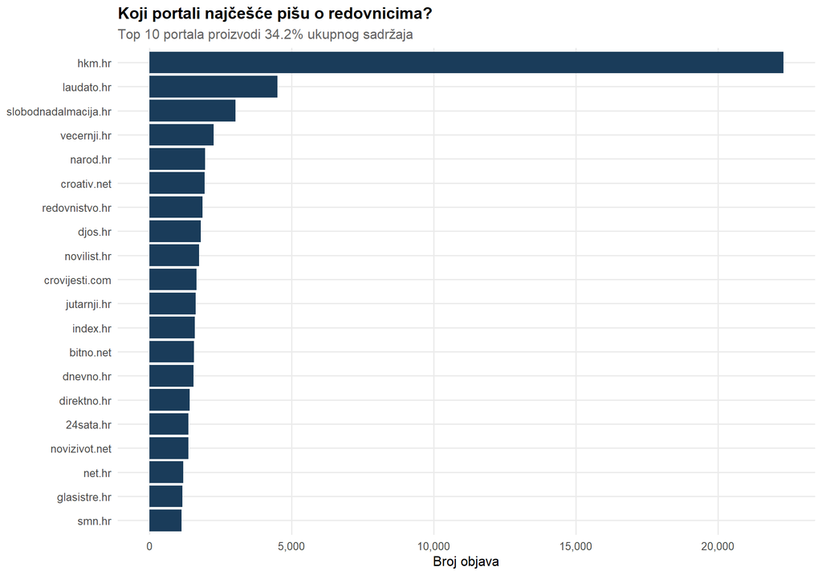

Figure 4: Top 20 portala po broju objava o redovničkim zajednicama

```r
portal_attention %>%
  head(20) %>%
  ggplot(aes(x = reorder(FROM, Posts), y = Posts)) +
  geom_col(fill = "#1a3c5a") +
  coord_flip() +
  scale_y_continuous(labels = comma) +
  labs(
    title = "Koji portali najčešće pišu o redovnicima?",
    subtitle = paste0("Top 10 portala proizvodi ", sprintf("%.1f%%", cr10_portals), " ukupnog sadržaja"),
    x = NULL,
    y = "Broj objava"
  )
```

Top 10 portala proizvodi 34.2% sadržaja, što ne potvrđuje hipotezu. HHI indeks od 377 ukazuje na nisku koncentraciju. **H1b je nije podržana**.

#### 3.1.2.1 Koncentracija po tipu portala

Razlikuje li se koncentracija pažnje među redovima ovisno o tipu portala? Ako mainstream portali pišu samo o najpoznatijim redovima dok religijski pokrivaju širi spektar, Gini koeficijent bi trebao biti viši za mainstream portale.

**Prikaži kod**

```r
gini_by_portal <- dta[ORDER != "Unknown" &
                      PORTAL_TYPE %in% c("Mainstream National", "Religious Catholic", "Regional", "Local"),
                      {
                        order_counts <- .SD[, .N, by = ORDER]
                        .(Gini = Gini(order_counts$N),
                          N_orders = uniqueN(ORDER),
                          N_posts = .N)
                      }, by = PORTAL_TYPE]

gini_by_portal %>%
  mutate(
    `Tip portala` = PORTAL_TYPE,
    `Gini koeficijent` = sprintf("%.3f", Gini),
    `Broj redova` = N_orders,
    `Broj objava` = format(N_posts, big.mark = ",")
  ) %>%
  select(`Tip portala`, `Gini koeficijent`, `Broj redova`, `Broj objava`) %>%
  kable(caption = "Koncentracija pažnje među redovima po tipu portala") %>%
  kable_styling(bootstrap_options = c("striped", "hover"), full_width = FALSE)
```

Koncentracija pažnje među redovima po tipu portala

| Tip portala | Gini koeficijent | Broj redova | Broj objava |
| --- | --- | --- | --- |
| Local | 0.778 | 26 | 74,496 |
| Regional | 0.790 | 25 | 8,952 |
| Mainstream National | 0.827 | 24 | 11,003 |
| Religious Catholic | 0.768 | 26 | 7,035 |

Mainstream portali pokazuju višu koncentraciju pažnje na manji broj redova, dok religijski portali pokrivaju širi spektar zajednica.

### 3.1.3 H1c Dvostruka koncentracija

Testiramo stvara li mali broj portala koji piše o malom broju redova medijsku elitu.

**Prikaži kod**

```r
portal_order_matrix <- dta[ORDER != "Unknown" & FROM != "", .(
  Posts = .N
), by = .(FROM, ORDER)]
setorder(portal_order_matrix, -Posts)

top5_portals <- portal_attention[1:5, FROM]
top5_orders <- order_attention[1:5, ORDER]

elite_posts <- sum(portal_order_matrix[FROM %in% top5_portals & ORDER %in% top5_orders, Posts])
total_posts_all <- sum(portal_order_matrix$Posts)
elite_share <- elite_posts / total_posts_all * 100

heatmap_data <- portal_order_matrix[FROM %in% top5_portals & ORDER %in% top5_orders]
```

**Prikaži kod**

```r
tibble(
  Metrika = c(
    "Top 5 portala × Top 5 redova",
    "Ukupno objava u elitnom prostoru",
    "Udio u ukupnom korpusu"
  ),
  Vrijednost = c(
    "25 kombinacija",
    format(elite_posts, big.mark = ","),
    sprintf("%.1f%%", elite_share)
  ),
  Prag = c("", "", "> 30%"),
  Rezultat = c("", "",
    ifelse(elite_share > 30, "✓ Podržana", "✗ Nije podržana")
  )
) %>%
  kable(caption = "H1c Dvostruka koncentracija",
        align = c("l", "r", "c", "l")) %>%
  kable_styling(bootstrap_options = c("striped", "hover"), full_width = FALSE)
```

H1c Dvostruka koncentracija

| Metrika | Vrijednost | Prag | Rezultat |
| --- | --- | --- | --- |
| Top 5 portala × Top 5 redova | 25 kombinacija |  |  |
| Ukupno objava u elitnom prostoru | 24,004 |  |  |
| Udio u ukupnom korpusu | 23.7% | > 30% | ✗ Nije podržana |

**Prikaži kod**

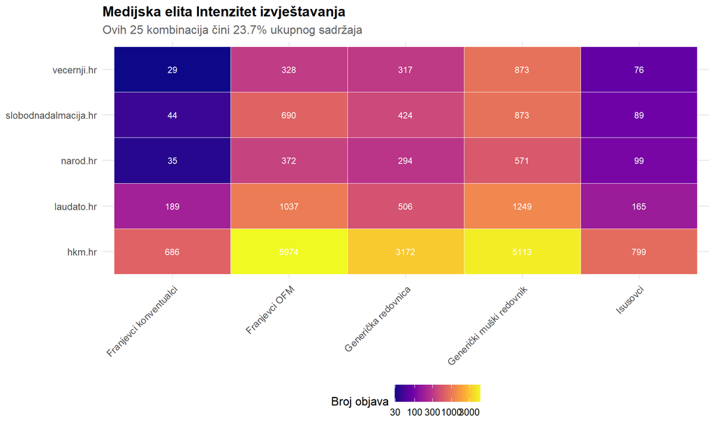

Figure 5: Heatmap medijske elite Top 5 portala × Top 5 redova

```r
ggplot(heatmap_data, aes(x = ORDER, y = FROM, fill = Posts)) +
  geom_tile(color = "white") +
  geom_text(aes(label = Posts), color = "white", size = 3) +
  scale_fill_viridis_c(option = "plasma", trans = "log10") +
  labs(
    title = "Medijska elita Intenzitet izvještavanja",
    subtitle = paste0("Ovih 25 kombinacija čini ", sprintf("%.1f%%", elite_share), " ukupnog sadržaja"),
    x = NULL, y = NULL, fill = "Broj objava"
  ) +
  theme(axis.text.x = element_text(angle = 45, hjust = 1))
```

Top 5 portala pišući o top 5 redova čini 23.7% ukupnog sadržaja, što ne potvrđuje postojanje medijske elite. **H1c je nije podržana**.

## 3.2 Blok 2 Spolne razlike

### 3.2.1 H2a Spolna asimetrija u volumenu

**Prikaži kod**

```r
gender_summary <- dta[GENDER %in% c("Male", "Female"), .(
  Posts = .N,
  Total_Interactions = sum(INTERACTIONS, na.rm = TRUE)
), by = GENDER]
gender_summary[, Share := Posts / sum(Posts) * 100]

male_share <- gender_summary[GENDER == "Male", Share]
female_share <- gender_summary[GENDER == "Female", Share]

gender_table <- table(dta[GENDER %in% c("Male", "Female")]$GENDER)
chisq_gender <- chisq.test(gender_table, p = c(0.5, 0.5))
cramers_v_gender <- cramers_v(chisq_gender, sum(gender_table), 2)
```

**Prikaži kod**

```r
## Wilson confidence intervals for proportions
n_gendered <- sum(gender_table)
n_male <- as.numeric(gender_table["Male"])
n_female <- as.numeric(gender_table["Female"])

wilson_male <- prop.test(n_male, n_gendered)
wilson_female <- prop.test(n_female, n_gendered)

tibble(
  Metrika = c(
    "Udio muških redova",
    "95% CI (Wilson)",
    "Udio ženskih redova",
    "95% CI (Wilson)",
    "Chi square statistika",
    "P vrijednost",
    "Cramérov V (veličina učinka)"
  ),
  Vrijednost = c(
    sprintf("%.1f%%", male_share),
    sprintf("[%.1f%%, %.1f%%]", wilson_male$conf.int[1] * 100, wilson_male$conf.int[2] * 100),
    sprintf("%.1f%%", female_share),
    sprintf("[%.1f%%, %.1f%%]", wilson_female$conf.int[1] * 100, wilson_female$conf.int[2] * 100),
    sprintf("%.2f", chisq_gender$statistic),
    ifelse(chisq_gender$p.value < 0.001, "< 0.001", sprintf("%.3f", chisq_gender$p.value)),
    sprintf("%.3f (%s)", cramers_v_gender,
            ifelse(cramers_v_gender > 0.30, "velik",
                   ifelse(cramers_v_gender > 0.10, "srednji", "mali")))
  ),
  Prag = c("> 60%", "", "", "", "", "< 0.05", ""),
  Rezultat = c(
    ifelse(male_share > 60, "✓ Podržana", "✗ Nije podržana"),
    "", "", "", "",
    ifelse(chisq_gender$p.value < 0.05, "✓ Značajno", "✗ Nije značajno"),
    ""
  )
) %>%
  kable(caption = "H2a Spolna asimetrija u volumenu",
        align = c("l", "r", "c", "l")) %>%
  kable_styling(bootstrap_options = c("striped", "hover"), full_width = FALSE)
```

H2a Spolna asimetrija u volumenu

| Metrika | Vrijednost | Prag | Rezultat |
| --- | --- | --- | --- |
| Udio muških redova | 76.0% | > 60% | ✓ Podržana |
| 95% CI (Wilson) | [75.7%, 76.3%] |  |  |
| Udio ženskih redova | 24.0% |  |  |
| 95% CI (Wilson) | [23.7%, 24.3%] |  |  |
| Chi square statistika | 27468.11 |  |  |
| P vrijednost | < 0.001 | < 0.05 | ✓ Značajno |
| Cramérov V (veličina učinka) | 0.520 (velik) |  |  |

**Prikaži kod**

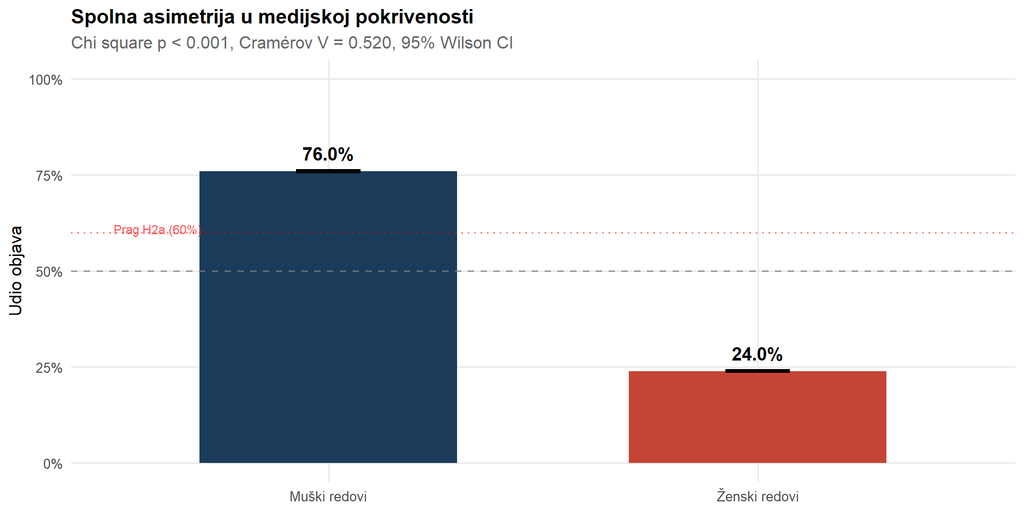

Figure 6: Raspodjela medijskog prostora po spolu redovnika s intervalima pouzdanosti

```r
gender_ci <- tibble(
  GENDER = c("Male", "Female"),
  Share = c(male_share, female_share),
  Lower = c(wilson_male$conf.int[1] * 100, wilson_female$conf.int[1] * 100),
  Upper = c(wilson_male$conf.int[2] * 100, wilson_female$conf.int[2] * 100),
  Label = c("Muški redovi", "Ženski redovi")
)

ggplot(gender_ci, aes(x = Label, y = Share, fill = GENDER)) +
  geom_col(width = 0.6) +
  geom_errorbar(aes(ymin = Lower, ymax = Upper), width = 0.15, linewidth = 0.8) +
  geom_text(aes(label = sprintf("%.1f%%", Share)), vjust = -0.8, fontface = "bold", size = 4.5) +
  geom_hline(yintercept = 50, linetype = "dashed", color = "gray50", alpha = 0.7) +
  geom_hline(yintercept = 60, linetype = "dotted", color = "red", alpha = 0.5) +
  annotate("text", x = 0.5, y = 61, label = "Prag H2a (60%)", color = "red",
           hjust = 0, size = 3, alpha = 0.7) +
  scale_fill_manual(values = gender_colors, guide = "none") +
  scale_y_continuous(limits = c(0, 100), labels = function(x) paste0(x, "%")) +
  labs(
    title = "Spolna asimetrija u medijskoj pokrivenosti",
    subtitle = paste0("Chi square p ", ifelse(chisq_gender$p.value < 0.001, "< 0.001",
                      sprintf("= %.3f", chisq_gender$p.value)),
                      ", Cramérov V = ", sprintf("%.3f", cramers_v_gender),
                      ", 95% Wilson CI"),
    x = NULL, y = "Udio objava"
  )
```

Muški redovi dobivaju 76.0% prostora, što prelazi prag od 60%. Razlika je statistički značajna s Cramérovim V od 0.520 što upućuje na velik učinak. **H2a je podržana**.

### 3.2.2 H2b Interakcija spol × tip portala

**Prikaži kod**

```r
gender_portal <- dta[GENDER %in% c("Male", "Female") &
                     PORTAL_TYPE %in% c("Mainstream National", "Religious Catholic", "Regional", "Local"),
                     .N, by = .(PORTAL_TYPE, GENDER)]
gender_portal[, Total := sum(N), by = PORTAL_TYPE]
gender_portal[, Share := N / Total * 100]

mainstream_male <- gender_portal[PORTAL_TYPE == "Mainstream National" & GENDER == "Male", Share]
religious_male <- gender_portal[PORTAL_TYPE == "Religious Catholic" & GENDER == "Male", Share]
regional_male <- gender_portal[PORTAL_TYPE == "Regional" & GENDER == "Male", Share]
local_male <- gender_portal[PORTAL_TYPE == "Local" & GENDER == "Male", Share]
if (length(regional_male) == 0) regional_male <- 0
if (length(local_male) == 0) local_male <- 0

ratio_diff <- mainstream_male - religious_male

contingency_table <- dta[GENDER %in% c("Male", "Female") &
                         PORTAL_TYPE %in% c("Mainstream National", "Religious Catholic", "Regional", "Local"),
                         .N, by = .(PORTAL_TYPE, GENDER)]
ct <- xtabs(N ~ PORTAL_TYPE + GENDER, data = contingency_table)
chisq_interaction <- chisq.test(ct)
cramers_v_interaction <- cramers_v(chisq_interaction, sum(ct), min(dim(ct)))
```

**Prikaži kod**

```r
tibble(
  Metrika = c(
    "Muški udio na mainstream portalima",
    "Muški udio na religijskim portalima",
    "Muški udio na regionalnim portalima",
    "Muški udio na lokalnim portalima",
    "Razlika mainstream vs religijski",
    "Chi square p vrijednost (sva 4 tipa)",
    "Cramérov V"
  ),
  Vrijednost = c(
    sprintf("%.1f%%", mainstream_male),
    sprintf("%.1f%%", religious_male),
    sprintf("%.1f%%", regional_male),
    sprintf("%.1f%%", local_male),
    sprintf("%.1f postotnih bodova", ratio_diff),
    ifelse(chisq_interaction$p.value < 0.001, "< 0.001",
           sprintf("%.3f", chisq_interaction$p.value)),
    sprintf("%.3f (%s)", cramers_v_interaction,
            ifelse(cramers_v_interaction > 0.30, "velik",
                   ifelse(cramers_v_interaction > 0.10, "srednji", "mali")))
  ),
  Rezultat = c("", "", "", "",
    ifelse(ratio_diff > 5, "✓ Veća na mainstream", "✗ Nema razlike"),
    ifelse(chisq_interaction$p.value < 0.05, "✓ Značajno", "✗ Nije značajno"),
    ""
  )
) %>%
  kable(caption = "H2b Spolna asimetrija po svim tipovima portala",
        align = c("l", "r", "l")) %>%
  kable_styling(bootstrap_options = c("striped", "hover"), full_width = FALSE)
```

H2b Spolna asimetrija po svim tipovima portala

| Metrika | Vrijednost | Rezultat |
| --- | --- | --- |
| Muški udio na mainstream portalima | 76.0% |  |
| Muški udio na religijskim portalima | 76.4% |  |
| Muški udio na regionalnim portalima | 76.3% |  |
| Muški udio na lokalnim portalima | 75.9% |  |
| Razlika mainstream vs religijski | -0.4 postotnih bodova | ✗ Nema razlike |
| Chi square p vrijednost (sva 4 tipa) | 0.734 | ✗ Nije značajno |
| Cramérov V | 0.004 (mali) |  |

**Prikaži kod**

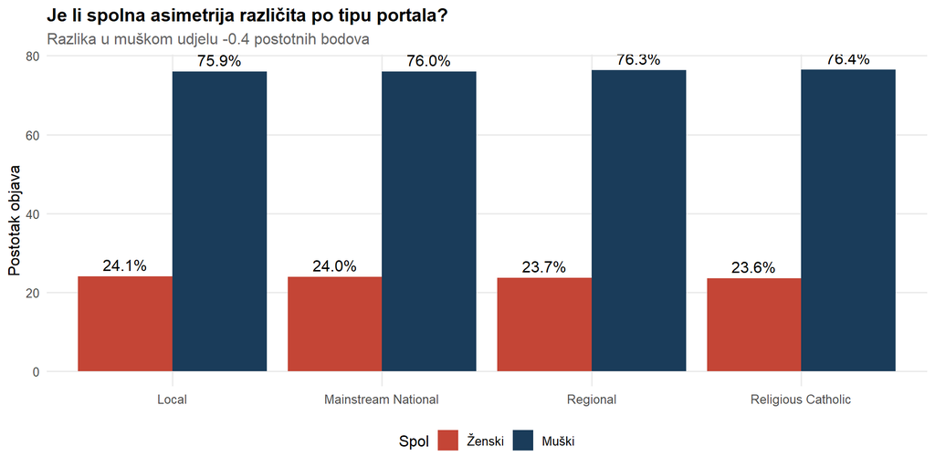

Figure 7: Spolni omjeri po tipu portala

```r
ggplot(gender_portal, aes(x = PORTAL_TYPE, y = Share, fill = GENDER)) +
  geom_col(position = "dodge") +
  scale_fill_manual(values = gender_colors, labels = c("Ženski", "Muški")) +
  geom_text(aes(label = sprintf("%.1f%%", Share)),
            position = position_dodge(width = 0.9), vjust = -0.5) +
  labs(
    title = "Je li spolna asimetrija različita po tipu portala?",
    subtitle = paste0("Razlika u muškom udjelu ", sprintf("%.1f", ratio_diff), " postotnih bodova"),
    x = NULL, y = "Postotak objava", fill = "Spol"
  )
```

Mainstream portali imaju 76.0% muških objava nasuprot 76.4% na religijskim, 76.3% na regionalnim i 75.9% na lokalnim portalima. Razlika od 0.4 postotnih bodova između mainstream i religijskih je statistički neznačajna s Cramérovim V od 0.004. **H2b je nije podržana**.

#### 3.2.2.1 Dinamika spolne asimetrije kroz vrijeme

**Prikaži kod**

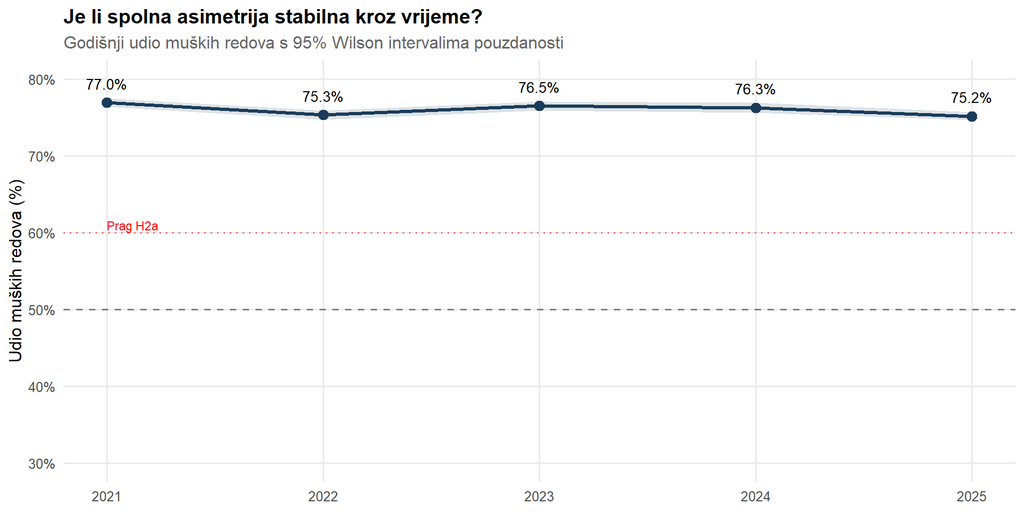

Udio muških redova po godini (s 95% CI)

```r
gender_yearly <- dta[GENDER %in% c("Male", "Female"),
                     .(N_male = sum(GENDER == "Male"),
                       N_total = .N),
                     by = year]
gender_yearly[, Male_Share := N_male / N_total * 100]

## Wilson CIs per year
gender_yearly[, `:=`(
  CI_lower = sapply(seq_len(.N), function(i) prop.test(N_male[i], N_total[i])$conf.int[1] * 100),
  CI_upper = sapply(seq_len(.N), function(i) prop.test(N_male[i], N_total[i])$conf.int[2] * 100)
)]

ggplot(gender_yearly, aes(x = year, y = Male_Share)) +
  geom_ribbon(aes(ymin = CI_lower, ymax = CI_upper), fill = "#1a3c5a", alpha = 0.15) +
  geom_line(color = "#1a3c5a", linewidth = 1.2) +
  geom_point(color = "#1a3c5a", size = 3) +
  geom_text(aes(label = sprintf("%.1f%%", Male_Share)), vjust = -1.2, size = 3.5) +
  geom_hline(yintercept = 50, linetype = "dashed", color = "gray50") +
  geom_hline(yintercept = 60, linetype = "dotted", color = "red", alpha = 0.5) +
  annotate("text", x = min(gender_yearly$year), y = 61, label = "Prag H2a",
           color = "red", hjust = 0, size = 3) +
  scale_x_continuous(breaks = gender_yearly$year) +
  scale_y_continuous(limits = c(30, 80), labels = function(x) paste0(x, "%")) +
  labs(
    title = "Je li spolna asimetrija stabilna kroz vrijeme?",
    subtitle = "Godišnji udio muških redova s 95% Wilson intervalima pouzdanosti",
    x = NULL, y = "Udio muških redova (%)"
  )
```

Spolna asimetrija je relativno stabilna kroz promatrano razdoblje, što sugerira da se radi o strukturnom, a ne cikličnom obrascu.

### 3.2.3 H2c Spolne razlike u angažmanu

**Prikaži kod**

```r
engagement_gender <- dta[GENDER %in% c("Male", "Female") &
                         !is.na(INTERACTIONS) & INTERACTIONS > 0,
                         .(GENDER, INTERACTIONS)]

male_interactions <- engagement_gender[GENDER == "Male", INTERACTIONS]
female_interactions <- engagement_gender[GENDER == "Female", INTERACTIONS]

mannwhitney_test <- wilcox.test(male_interactions, female_interactions, alternative = "greater")

median_male <- median(male_interactions)
median_female <- median(female_interactions)
mean_male <- mean(male_interactions)
mean_female <- mean(female_interactions)

## Rank biserial correlation as effect size
r_biserial_gender <- rank_biserial(mannwhitney_test, length(male_interactions), length(female_interactions))
```

**Prikaži kod**

```r
tibble(
  Metrika = c(
    "Medijan interakcija (muški)",
    "Medijan interakcija (ženski)",
    "Omjer medijana (M/Ž)",
    "Prosječne interakcije (muški)",
    "Prosječne interakcije (ženski)",
    "Mann Whitney U p vrijednost",
    "Rang biserijalna korelacija"
  ),
  Vrijednost = c(
    sprintf("%.0f", median_male),
    sprintf("%.0f", median_female),
    sprintf("%.2f", median_male / max(median_female, 1)),
    sprintf("%.1f", mean_male),
    sprintf("%.1f", mean_female),
    ifelse(mannwhitney_test$p.value < 0.001, "< 0.001",
           sprintf("%.3f", mannwhitney_test$p.value)),
    sprintf("%.3f (%s)", r_biserial_gender,
            ifelse(r_biserial_gender > 0.30, "velik",
                   ifelse(r_biserial_gender > 0.10, "srednji", "mali")))
  ),
  Rezultat = c("", "", "", "", "",
    ifelse(mannwhitney_test$p.value < 0.05, "✓ Značajno", "✗ Nije značajno"),
    ""
  )
) %>%
  kable(caption = "H2c Spolne razlike u angažmanu",
        align = c("l", "r", "l")) %>%
  kable_styling(bootstrap_options = c("striped", "hover"), full_width = FALSE)
```

H2c Spolne razlike u angažmanu

| Metrika | Vrijednost | Rezultat |
| --- | --- | --- |
| Medijan interakcija (muški) | 38 |  |
| Medijan interakcija (ženski) | 38 |  |
| Omjer medijana (M/Ž) | 1.00 |  |
| Prosječne interakcije (muški) | 207.2 |  |
| Prosječne interakcije (ženski) | 187.0 |  |
| Mann Whitney U p vrijednost | 0.371 | ✗ Nije značajno |
| Rang biserijalna korelacija | 0.002 (mali) |  |

**Prikaži kod**

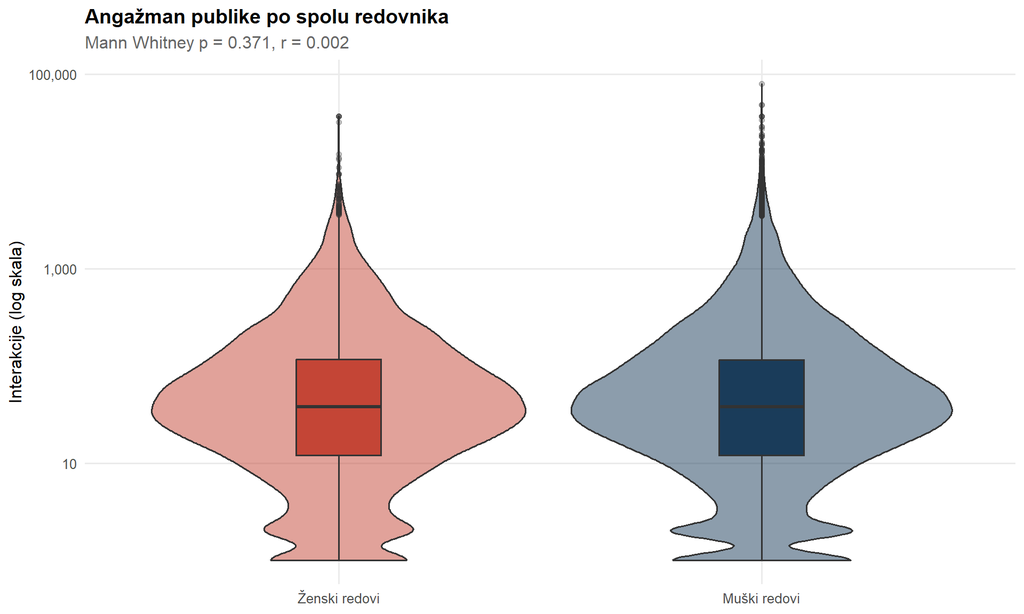

Figure 8: Distribucija angažmana po spolu (logaritamska skala)

```r
ggplot(engagement_gender, aes(x = GENDER, y = INTERACTIONS, fill = GENDER)) +
  geom_violin(alpha = 0.5) +
  geom_boxplot(width = 0.2, outlier.alpha = 0.3) +
  scale_y_log10(labels = comma) +
  scale_fill_manual(values = gender_colors, labels = c("Ženski", "Muški"), guide = "none") +
  scale_x_discrete(labels = c("Ženski redovi", "Muški redovi")) +
  labs(
    title = "Angažman publike po spolu redovnika",
    subtitle = paste0("Mann Whitney p ",
                      ifelse(mannwhitney_test$p.value < 0.001, "< 0.001",
                             sprintf("= %.3f", mannwhitney_test$p.value)),
                      ", r = ", sprintf("%.3f", r_biserial_gender)),
    x = NULL, y = "Interakcije (log skala)"
  )
```

Medijan interakcija za muške redove je 38, a za ženske 38. Razlika nije statistički značajna s rang biserijalnom korelacijom od 0.002 (mali učinak). **H2c je nije podržana**.

## 3.3 Blok 3 Tipologija portala

### 3.3.1 H3a Različita tematska struktura

Testiramo pišu li mainstream portali češće o kontroverzama. Koristimo eksplicitni indikator kontroverznog sadržaja temeljen na ključnim riječima (skandal, zlostavljanje, istraga, optužba, tužba, kaznena, sud, presuda, imovina, financij, pronevjera, korupcija, sukob, spor) te dopunjujemo s automatiziranim sentimentom.

**Prikaži kod**

```r
## Controversy indicator analysis
controversy_portal <- dta[PORTAL_TYPE %in% c("Mainstream National", "Religious Catholic", "Regional", "Local"),
                          .(Total = .N,
                            Controversy = sum(IS_CONTROVERSY),
                            Controversy_Rate = mean(IS_CONTROVERSY) * 100),
                          by = PORTAL_TYPE]

ct_controversy <- xtabs(~ PORTAL_TYPE + IS_CONTROVERSY,
                        data = dta[PORTAL_TYPE %in% c("Mainstream National", "Religious Catholic", "Regional", "Local")])
chisq_controversy <- chisq.test(ct_controversy)
cramers_v_controversy <- cramers_v(chisq_controversy, sum(ct_controversy), min(dim(ct_controversy)))

mainstream_contr <- controversy_portal[PORTAL_TYPE == "Mainstream National", Controversy_Rate]
religious_contr <- controversy_portal[PORTAL_TYPE == "Religious Catholic", Controversy_Rate]
regional_contr <- controversy_portal[PORTAL_TYPE == "Regional", Controversy_Rate]
local_contr <- controversy_portal[PORTAL_TYPE == "Local", Controversy_Rate]
if (length(mainstream_contr) == 0) mainstream_contr <- 0
if (length(religious_contr) == 0) religious_contr <- 0
if (length(regional_contr) == 0) regional_contr <- 0
if (length(local_contr) == 0) local_contr <- 0

contr_diff <- mainstream_contr - religious_contr

## Also show sentiment as supplementary
theme_portal <- dta[!is.na(AUTO_SENTIMENT) &
                    PORTAL_TYPE %in% c("Mainstream National", "Religious Catholic", "Regional", "Local"),
                    .N, by = .(PORTAL_TYPE, AUTO_SENTIMENT)]
theme_portal[, Total := sum(N), by = PORTAL_TYPE]
theme_portal[, Share := N / Total * 100]
```

**Prikaži kod**

```r
tibble(
  Metrika = c(
    "Udio kontroverznih objava mainstream",
    "Udio kontroverznih objava religijski",
    "Udio kontroverznih objava regionalni",
    "Udio kontroverznih objava lokalni",
    "Razlika mainstream vs religijski",
    "Chi square p (svi tipovi)",
    "Cramérov V"
  ),
  Vrijednost = c(
    sprintf("%.1f%%", mainstream_contr),
    sprintf("%.1f%%", religious_contr),
    sprintf("%.1f%%", regional_contr),
    sprintf("%.1f%%", local_contr),
    sprintf("%.1f postotnih bodova", contr_diff),
    ifelse(chisq_controversy$p.value < 0.001, "< 0.001",
           sprintf("%.3f", chisq_controversy$p.value)),
    sprintf("%.3f (%s)", cramers_v_controversy,
            ifelse(cramers_v_controversy > 0.30, "velik",
                   ifelse(cramers_v_controversy > 0.10, "srednji", "mali")))
  ),
  Rezultat = c("", "", "", "",
    ifelse(contr_diff > 3, "✓ Više na mainstream", "✗ Nema razlike"),
    ifelse(chisq_controversy$p.value < 0.05, "✓ Značajno", "✗ Nije značajno"),
    ""
  )
) %>%
  kable(caption = "H3a Kontroverznost po tipu portala",
        align = c("l", "r", "l")) %>%
  kable_styling(bootstrap_options = c("striped", "hover"), full_width = FALSE)
```

H3a Kontroverznost po tipu portala

| Metrika | Vrijednost | Rezultat |
| --- | --- | --- |
| Udio kontroverznih objava mainstream | 29.0% |  |
| Udio kontroverznih objava religijski | 9.5% |  |
| Udio kontroverznih objava regionalni | 18.3% |  |
| Udio kontroverznih objava lokalni | 18.2% |  |
| Razlika mainstream vs religijski | 19.5 postotnih bodova | ✓ Više na mainstream |
| Chi square p (svi tipovi) | < 0.001 | ✓ Značajno |
| Cramérov V | 0.107 (srednji) |  |

**Prikaži kod**

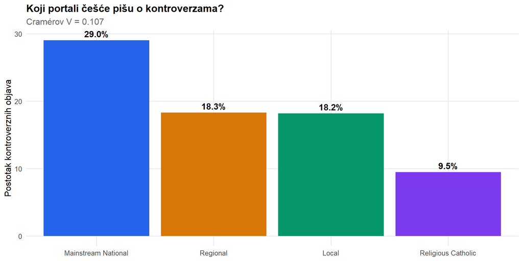

Figure 9: Udio kontroverznog sadržaja po tipu portala

```r
ggplot(controversy_portal, aes(x = reorder(PORTAL_TYPE, -Controversy_Rate),
                                y = Controversy_Rate, fill = PORTAL_TYPE)) +
  geom_col() +
  geom_text(aes(label = sprintf("%.1f%%", Controversy_Rate)), vjust = -0.5, fontface = "bold") +
  scale_fill_manual(values = portal_type_colors, guide = "none") +
  labs(
    title = "Koji portali češće pišu o kontroverzama?",
    subtitle = paste0("Cramérov V = ", sprintf("%.3f", cramers_v_controversy)),
    x = NULL,
    y = "Postotak kontroverznih objava"
  )
```

**Prikaži kod**

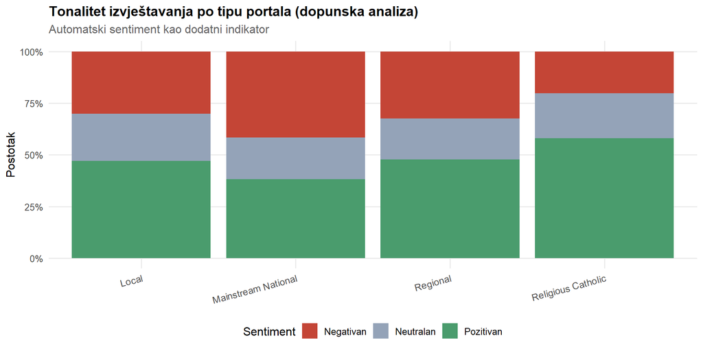

Figure 10: Distribucija sentimenta po tipu portala (dopunska analiza)

```r
ggplot(theme_portal, aes(x = PORTAL_TYPE, y = Share, fill = AUTO_SENTIMENT)) +
  geom_col(position = "fill") +
  scale_fill_manual(values = c("negative" = "#c44536", "neutral" = "#94a3b8", "positive" = "#4a9c6d"),
                    labels = c("Negativan", "Neutralan", "Pozitivan")) +
  scale_y_continuous(labels = percent) +
  labs(
    title = "Tonalitet izvještavanja po tipu portala (dopunska analiza)",
    subtitle = "Automatski sentiment kao dodatni indikator",
    x = NULL, y = "Postotak", fill = "Sentiment"
  ) +
  theme(axis.text.x = element_text(angle = 15, hjust = 1))
```

Mainstream portali imaju 29.0% kontroverznog sadržaja nasuprot 9.5% na religijskim, 18.3% na regionalnim i 18.2% na lokalnim portalima. Razlika je statistički značajna s Cramérovim V od 0.107. **H3a je podržana**.

#### 3.3.1.1 Interakcija spol × kontroverznost

Dodatna analiza ispituje jesu li kontroverze nerazmjerno vezane uz muške redove, što bi moglo dijelom objašnjavati spolnu asimetriju u angažmanu (H2c).

**Prikaži kod**

```r
gender_contr <- dta[GENDER %in% c("Male", "Female"),
                    .(Total = .N,
                      Controversy = sum(IS_CONTROVERSY),
                      Controversy_Rate = mean(IS_CONTROVERSY) * 100,
                      Median_Int_Contr = median(INTERACTIONS[IS_CONTROVERSY == TRUE], na.rm = TRUE),
                      Median_Int_Non = median(INTERACTIONS[IS_CONTROVERSY == FALSE], na.rm = TRUE)),
                    by = GENDER]

ct_gxc <- xtabs(~ GENDER + IS_CONTROVERSY, data = dta[GENDER %in% c("Male", "Female")])
chisq_gxc <- chisq.test(ct_gxc)
cramers_v_gxc <- cramers_v(chisq_gxc, sum(ct_gxc), min(dim(ct_gxc)))

tibble(
  Spol = c("Muški", "Ženski"),
  `Ukupno objava` = format(gender_contr$Total, big.mark = ","),
  `Kontroverzne objave` = format(gender_contr$Controversy, big.mark = ","),
  `Udio kontr. (%)` = sprintf("%.1f%%", gender_contr$Controversy_Rate),
  `Medijan inter. (kontr.)` = sprintf("%.0f", gender_contr$Median_Int_Contr),
  `Medijan inter. (nekontr.)` = sprintf("%.0f", gender_contr$Median_Int_Non)
) %>%
  kable(caption = paste0("Interakcija spol × kontroverznost (Cramérov V = ",
                          sprintf("%.3f", cramers_v_gxc), ")")) %>%
  kable_styling(bootstrap_options = c("striped", "hover"), full_width = FALSE)
```

Interakcija spol × kontroverznost (Cramérov V = 0.032)

[output not shown]

### 3.3.2 H3b Različit sentiment

**Prikaži kod**

```r
mainstream_positive <- theme_portal[PORTAL_TYPE == "Mainstream National" & AUTO_SENTIMENT == "positive", Share]
religious_positive <- theme_portal[PORTAL_TYPE == "Religious Catholic" & AUTO_SENTIMENT == "positive", Share]
regional_positive <- theme_portal[PORTAL_TYPE == "Regional" & AUTO_SENTIMENT == "positive", Share]
local_positive <- theme_portal[PORTAL_TYPE == "Local" & AUTO_SENTIMENT == "positive", Share]

if (length(mainstream_positive) == 0) mainstream_positive <- 0
if (length(religious_positive) == 0) religious_positive <- 0
if (length(regional_positive) == 0) regional_positive <- 0
if (length(local_positive) == 0) local_positive <- 0

sentiment_diff <- religious_positive - mainstream_positive

ct_sentiment <- xtabs(N ~ PORTAL_TYPE + AUTO_SENTIMENT, data = theme_portal)
chisq_sentiment <- chisq.test(ct_sentiment)
cramers_v_sentiment <- cramers_v(chisq_sentiment, sum(ct_sentiment), min(dim(ct_sentiment)))
```

**Prikaži kod**

```r
tibble(
  Metrika = c(
    "Pozitivan ton mainstream portali",
    "Pozitivan ton religijski portali",
    "Pozitivan ton regionalni portali",
    "Pozitivan ton lokalni portali",
    "Razlika religijski vs mainstream",
    "Chi square p (svi tipovi × sentiment)",
    "Cramérov V"
  ),
  Vrijednost = c(
    sprintf("%.1f%%", mainstream_positive),
    sprintf("%.1f%%", religious_positive),
    sprintf("%.1f%%", regional_positive),
    sprintf("%.1f%%", local_positive),
    sprintf("%.1f postotnih bodova", sentiment_diff),
    ifelse(chisq_sentiment$p.value < 0.001, "< 0.001",
           sprintf("%.3f", chisq_sentiment$p.value)),
    sprintf("%.3f (%s)", cramers_v_sentiment,
            ifelse(cramers_v_sentiment > 0.30, "velik",
                   ifelse(cramers_v_sentiment > 0.10, "srednji", "mali")))
  ),
  Prag = c("", "", "", "", "> 15 pp", "", ""),
  Rezultat = c("", "", "", "",
    ifelse(sentiment_diff > 15, "✓ Podržana", "✗ Nije podržana"),
    ifelse(chisq_sentiment$p.value < 0.05, "✓ Značajno", "✗ Nije značajno"),
    ""
  )
) %>%
  kable(caption = "H3b Različit sentiment po tipu portala",
        align = c("l", "r", "c", "l")) %>%
  kable_styling(bootstrap_options = c("striped", "hover"), full_width = FALSE)
```

H3b Različit sentiment po tipu portala

| Metrika | Vrijednost | Prag | Rezultat |
| --- | --- | --- | --- |
| Pozitivan ton mainstream portali | 38.2% |  |  |
| Pozitivan ton religijski portali | 58.0% |  |  |
| Pozitivan ton regionalni portali | 47.8% |  |  |
| Pozitivan ton lokalni portali | 47.1% |  |  |
| Razlika religijski vs mainstream | 19.9 postotnih bodova | > 15 pp | ✓ Podržana |
| Chi square p (svi tipovi × sentiment) | < 0.001 |  | ✓ Značajno |
| Cramérov V | 0.061 (mali) |  |  |

**Prikaži kod**

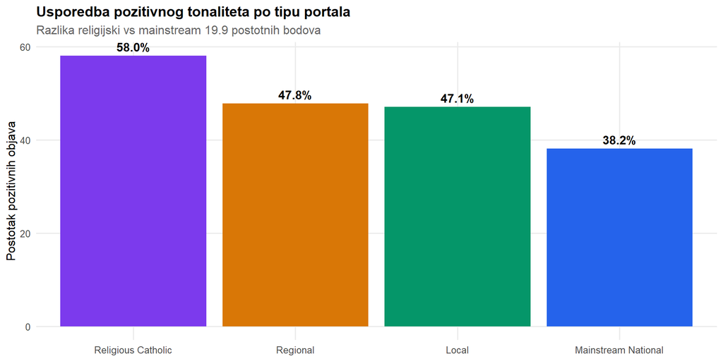

Figure 11: Usporedba pozitivnog sentimenta po svim tipovima portala

```r
sentiment_comparison <- theme_portal[AUTO_SENTIMENT == "positive"]

ggplot(sentiment_comparison, aes(x = reorder(PORTAL_TYPE, -Share), y = Share, fill = PORTAL_TYPE)) +
  geom_col() +
  geom_text(aes(label = sprintf("%.1f%%", Share)), vjust = -0.5, fontface = "bold") +
  scale_fill_manual(values = portal_type_colors, guide = "none") +
  labs(
    title = "Usporedba pozitivnog tonaliteta po tipu portala",
    subtitle = paste0("Razlika religijski vs mainstream ", sprintf("%.1f", sentiment_diff), " postotnih bodova"),
    x = NULL, y = "Postotak pozitivnih objava"
  )
```

Religijski portali imaju 58.0% pozitivnog tona nasuprot 38.2% na mainstream, 47.8% na regionalnim i 47.1% na lokalnim portalima. Cramérov V od 0.061 upućuje na mali učinak. **H3b je podržana**.

### 3.3.3 H3c Različita dubina izvještavanja

**Prikaži kod**

```r
depth_portal <- dta[!is.na(TEXT_LENGTH) & TEXT_LENGTH > 0 &
                    PORTAL_TYPE %in% c("Mainstream National", "Religious Catholic", "Regional", "Local")]

mainstream_length <- depth_portal[PORTAL_TYPE == "Mainstream National", TEXT_LENGTH]
religious_length <- depth_portal[PORTAL_TYPE == "Religious Catholic", TEXT_LENGTH]
regional_length <- depth_portal[PORTAL_TYPE == "Regional", TEXT_LENGTH]
local_length <- depth_portal[PORTAL_TYPE == "Local", TEXT_LENGTH]

mannwhitney_depth <- wilcox.test(religious_length, mainstream_length, alternative = "greater")
r_biserial_depth <- rank_biserial(mannwhitney_depth, length(religious_length), length(mainstream_length))

median_mainstream <- median(mainstream_length)
median_religious <- median(religious_length)
median_regional <- median(regional_length, na.rm = TRUE)
median_local <- median(local_length, na.rm = TRUE)

kruskal_depth <- kruskal.test(TEXT_LENGTH ~ PORTAL_TYPE, data = depth_portal)
## Eta squared from Kruskal Wallis as effect size
eta2_kruskal <- as.numeric(kruskal_depth$statistic) / (nrow(depth_portal) - 1)
```

Dunnov post hoc test za parne usporedbe:

**Prikaži kod**

```r
dunn_results <- dunn.test(depth_portal$TEXT_LENGTH, depth_portal$PORTAL_TYPE,
                          method = "bh", alpha = 0.05, kw = FALSE,
                          table = FALSE, list = TRUE)
```

```
                           Comparison of x by group
                             (Benjamini-Hochberg)

List of pairwise comparisons: Z statistic (adjusted p-value)
--------------------------------------------------------------
Local - Mainstream National              :  1.682780 (0.0462)
Local - Regional                         :  15.94215 (0.0000)*
Mainstream National - Regional           :  11.31078 (0.0000)*
Local - Religious Catholic               :  34.15976 (0.0000)*
Mainstream National - Religious Catholic :  27.14657 (0.0000)*
Regional - Religious Catholic            :  16.22765 (0.0000)*

alpha = 0.05
Reject Ho if p <= alpha/2
```

**Prikaži kod**

```r
dunn_df <- tibble(
  Usporedba = dunn_results$comparisons,
  Z = sprintf("%.2f", dunn_results$Z),
  `P (nekorigirano)` = ifelse(dunn_results$P < 0.001, "< 0.001",
                                sprintf("%.3f", dunn_results$P)),
  `P (BH korigirano)` = ifelse(dunn_results$P.adjusted < 0.001, "< 0.001",
                                 sprintf("%.3f", dunn_results$P.adjusted)),
  Značajno = ifelse(dunn_results$P.adjusted < 0.05, "✓", "")
)

dunn_df %>%
  kable(caption = "Dunnov post hoc test parnih usporedbi duljine tekstova") %>%
  kable_styling(bootstrap_options = c("striped", "hover"), full_width = FALSE)
```

Dunnov post hoc test parnih usporedbi duljine tekstova

| Usporedba | Z | P (nekorigirano) | P (BH korigirano) | Značajno |
| --- | --- | --- | --- | --- |
| Local - Mainstream National | 1.68 | 0.046 | 0.046 | ✓ |
| Local - Regional | 15.94 | < 0.001 | < 0.001 | ✓ |
| Mainstream National - Regional | 11.31 | < 0.001 | < 0.001 | ✓ |
| Local - Religious Catholic | 34.16 | < 0.001 | < 0.001 | ✓ |
| Mainstream National - Religious Catholic | 27.15 | < 0.001 | < 0.001 | ✓ |
| Regional - Religious Catholic | 16.23 | < 0.001 | < 0.001 | ✓ |

**Prikaži kod**

```r
tibble(
  Metrika = c(
    "Medijan duljine mainstream",
    "Medijan duljine religijski",
    "Medijan duljine regionalni",
    "Medijan duljine lokalni",
    "Mann Whitney p (religijski > mainstream)",
    "Rang biserijalna korelacija",
    "Kruskal Wallis p (svi tipovi)",
    "Eta squared (Kruskal Wallis)"
  ),
  Vrijednost = c(
    sprintf("%.0f znakova", median_mainstream),
    sprintf("%.0f znakova", median_religious),
    sprintf("%.0f znakova", median_regional),
    sprintf("%.0f znakova", median_local),
    ifelse(mannwhitney_depth$p.value < 0.001, "< 0.001",
           sprintf("%.3f", mannwhitney_depth$p.value)),
    sprintf("%.3f (%s)", r_biserial_depth,
            ifelse(r_biserial_depth > 0.30, "velik",
                   ifelse(r_biserial_depth > 0.10, "srednji", "mali"))),
    ifelse(kruskal_depth$p.value < 0.001, "< 0.001",
           sprintf("%.3f", kruskal_depth$p.value)),
    sprintf("%.4f", eta2_kruskal)
  ),
  Rezultat = c("", "", "", "",
    ifelse(mannwhitney_depth$p.value < 0.05, "✓ Značajno", "✗ Nije značajno"),
    "",
    ifelse(kruskal_depth$p.value < 0.05, "✓ Značajno", "✗ Nije značajno"),
    ""
  )
) %>%
  kable(caption = "H3c Dubina izvještavanja po tipu portala",
        align = c("l", "r", "l")) %>%
  kable_styling(bootstrap_options = c("striped", "hover"), full_width = FALSE)
```

H3c Dubina izvještavanja po tipu portala

| Metrika | Vrijednost | Rezultat |
| --- | --- | --- |
| Medijan duljine mainstream | 3933 znakova |  |
| Medijan duljine religijski | 2905 znakova |  |
| Medijan duljine regionalni | 3554 znakova |  |
| Medijan duljine lokalni | 4097 znakova |  |
| Mann Whitney p (religijski > mainstream) | 1.000 | ✗ Nije značajno |
| Rang biserijalna korelacija | 0.215 (srednji) |  |
| Kruskal Wallis p (svi tipovi) | < 0.001 | ✓ Značajno |
| Eta squared (Kruskal Wallis) | 0.0106 |  |

**Prikaži kod**

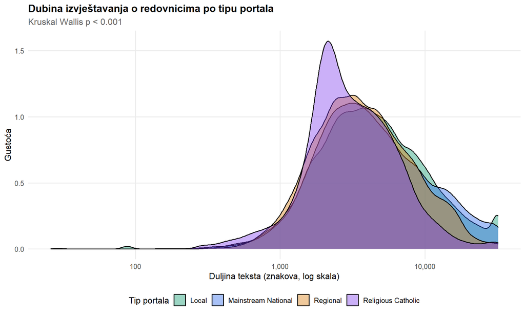

Figure 12: Distribucija duljine tekstova po tipu portala

```r
ggplot(depth_portal, aes(x = TEXT_LENGTH, fill = PORTAL_TYPE)) +
  geom_density(alpha = 0.4) +
  scale_x_log10(labels = comma) +
  scale_fill_manual(values = portal_type_colors) +
  labs(
    title = "Dubina izvještavanja o redovnicima po tipu portala",
    subtitle = paste0("Kruskal Wallis p ",
                      ifelse(kruskal_depth$p.value < 0.001, "< 0.001",
                             sprintf("= %.3f", kruskal_depth$p.value))),
    x = "Duljina teksta (znakova, log skala)",
    y = "Gustoća",
    fill = "Tip portala"
  )
```

**Prikaži kod**

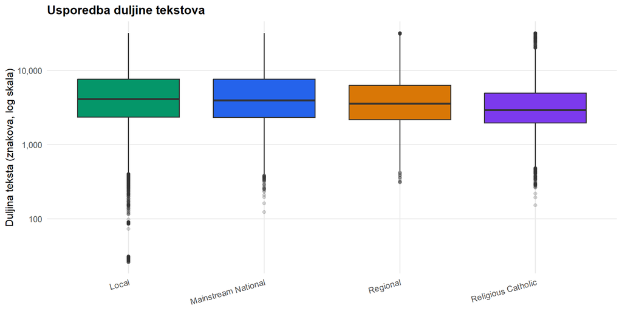

Figure 13: Boxplot duljine tekstova po tipu portala

```r
ggplot(depth_portal, aes(x = PORTAL_TYPE, y = TEXT_LENGTH, fill = PORTAL_TYPE)) +
  geom_boxplot(outlier.alpha = 0.2) +
  scale_y_log10(labels = comma) +
  scale_fill_manual(values = portal_type_colors, guide = "none") +
  labs(title = "Usporedba duljine tekstova",
       x = NULL, y = "Duljina teksta (znakova, log skala)") +
  theme(axis.text.x = element_text(angle = 15, hjust = 1))
```

**Prikaži kod**

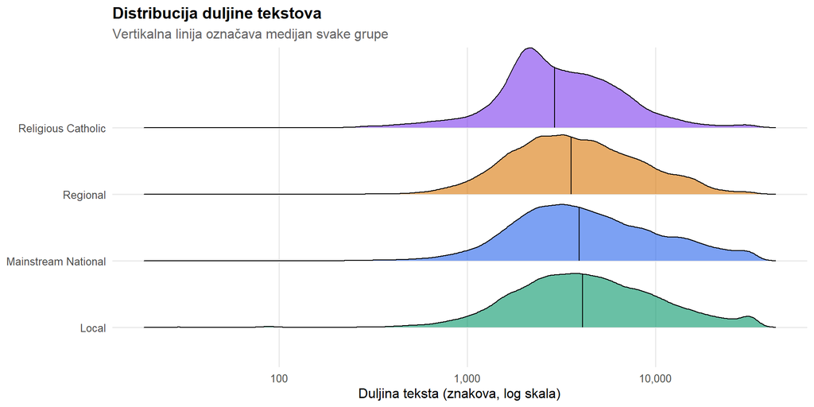

Figure 14: Ridgeline prikaz distribucije duljine tekstova po tipu portala

```r
ggplot(depth_portal, aes(x = TEXT_LENGTH, y = PORTAL_TYPE, fill = PORTAL_TYPE)) +
  geom_density_ridges(alpha = 0.6, scale = 1.2, quantile_lines = TRUE, quantiles = 2) +
  scale_x_log10(labels = comma) +
  scale_fill_manual(values = portal_type_colors, guide = "none") +
  labs(
    title = "Distribucija duljine tekstova",
    subtitle = "Vertikalna linija označava medijan svake grupe",
    x = "Duljina teksta (znakova, log skala)",
    y = NULL
  )
```

Religijski portali imaju medijan od 2905 znakova nasuprot 3933 na mainstream, 3554 na regionalnim i 4097 na lokalnim portalima. Rang biserijalna korelacija od 0.215 upućuje na srednji učinak. **H3c je nije podržana**.

## 3.4 Temporalna dinamika

Ovaj odjeljak prikazuje kako se ključne varijable mijenjaju kroz vrijeme. Budući da raspolažemo podacima od 2021. do 2025., možemo provjeriti je li koncentracija pažnje stabilna ili se mijenja te postoje li sezonski obrasci u izvještavanju.

**Prikaži kod**

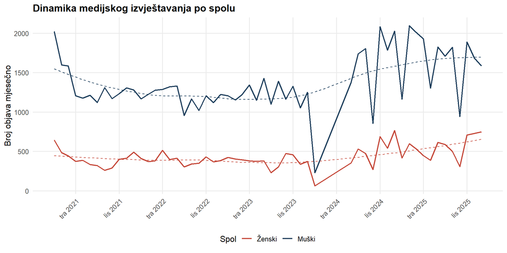

Mjesečni volumen objava po spolu

```r
temporal_gender <- dta[GENDER %in% c("Male", "Female"),
                       .(Posts = .N),
                       by = .(GENDER, yearmonth = floor_date(DATE, "month"))]

ggplot(temporal_gender, aes(x = yearmonth, y = Posts, color = GENDER)) +
  geom_line(linewidth = 0.8) +
  geom_smooth(method = "loess", se = FALSE, linetype = "dashed", linewidth = 0.5) +
  scale_color_manual(values = gender_colors, labels = c("Ženski", "Muški")) +
  scale_x_date(date_labels = "%b %Y", date_breaks = "6 months") +
  labs(
    title = "Dinamika medijskog izvještavanja po spolu",
    x = NULL, y = "Broj objava mjesečno", color = "Spol"
  ) +
  theme(axis.text.x = element_text(angle = 45, hjust = 1))
```

**Prikaži kod**

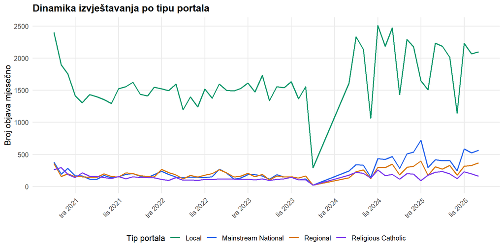

Mjesečni volumen objava po tipu portala

```r
temporal_portal <- dta[PORTAL_TYPE %in% c("Mainstream National", "Religious Catholic", "Regional", "Local"),
                       .(Posts = .N),
                       by = .(PORTAL_TYPE, yearmonth = floor_date(DATE, "month"))]

ggplot(temporal_portal, aes(x = yearmonth, y = Posts, color = PORTAL_TYPE)) +
  geom_line(linewidth = 0.8) +
  scale_color_manual(values = portal_type_colors) +
  scale_x_date(date_labels = "%b %Y", date_breaks = "6 months") +
  labs(
    title = "Dinamika izvještavanja po tipu portala",
    x = NULL, y = "Broj objava mjesečno", color = "Tip portala"
  ) +
  theme(axis.text.x = element_text(angle = 45, hjust = 1))
```

**Prikaži kod**

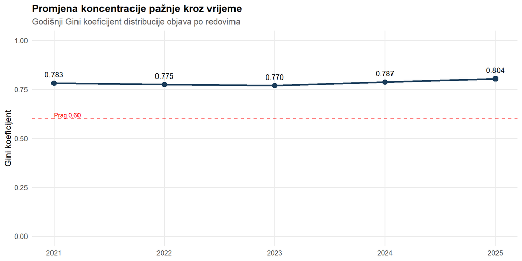

Godišnji Gini koeficijent koncentracije među redovima

```r
yearly_gini <- dta[ORDER != "Unknown", {
  order_counts <- .SD[, .N, by = ORDER]
  .(Gini = Gini(order_counts$N),
    N_orders = uniqueN(ORDER),
    N_posts = .N)
}, by = year]

ggplot(yearly_gini, aes(x = year, y = Gini)) +
  geom_line(color = "#1a3c5a", linewidth = 1.2) +
  geom_point(color = "#1a3c5a", size = 3) +
  geom_text(aes(label = sprintf("%.3f", Gini)), vjust = -1, size = 3.5) +
  geom_hline(yintercept = 0.60, linetype = "dashed", color = "red", alpha = 0.5) +
  annotate("text", x = min(yearly_gini$year), y = 0.62,
           label = "Prag 0.60", color = "red", hjust = 0, size = 3) +
  scale_x_continuous(breaks = yearly_gini$year) +
  ylim(c(0, 1)) +
  labs(
    title = "Promjena koncentracije pažnje kroz vrijeme",
    subtitle = "Godišnji Gini koeficijent distribucije objava po redovima",
    x = NULL, y = "Gini koeficijent"
  )
```

**Prikaži kod**

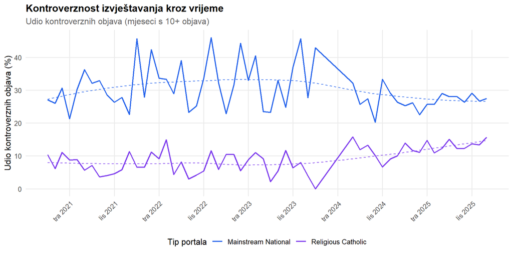

Mjesečni udio kontroverznih objava po tipu portala

```r
temporal_controversy <- dta[PORTAL_TYPE %in% c("Mainstream National", "Religious Catholic"),
                            .(Controversy_Rate = mean(IS_CONTROVERSY) * 100,
                              N = .N),
                            by = .(PORTAL_TYPE, yearmonth = floor_date(DATE, "month"))]

## Only plot months with sufficient data
temporal_controversy <- temporal_controversy[N >= 10]

ggplot(temporal_controversy, aes(x = yearmonth, y = Controversy_Rate, color = PORTAL_TYPE)) +
  geom_line(linewidth = 0.8) +
  geom_smooth(method = "loess", se = FALSE, linetype = "dashed", linewidth = 0.5) +
  scale_color_manual(values = portal_type_colors[c("Mainstream National", "Religious Catholic")]) +
  scale_x_date(date_labels = "%b %Y", date_breaks = "6 months") +
  labs(
    title = "Kontroverznost izvještavanja kroz vrijeme",
    subtitle = "Udio kontroverznih objava (mjeseci s 10+ objava)",
    x = NULL, y = "Udio kontroverznih objava (%)", color = "Tip portala"
  ) +
  theme(axis.text.x = element_text(angle = 45, hjust = 1))
```

# 4 Rasprava

## 4.1 Sažetak nalaza

**Prikaži kod**

```r
## Collect all raw p-values for BH correction
raw_pvals <- c(
  H1a = NA,  ## Gini has no single p-value; use power law test
  H1b = NA,  ## Concentration ratio, no single p-value
  H1c = NA,  ## Share threshold, no single p-value
  H2a = chisq_gender$p.value,
  H2b = chisq_interaction$p.value,
  H2c = mannwhitney_test$p.value,
  H3a = chisq_controversy$p.value,
  H3b = chisq_sentiment$p.value,
  H3c = mannwhitney_depth$p.value
)

## BH correction only on hypotheses with formal p-values (H2a through H3c)
pvals_to_correct <- raw_pvals[!is.na(raw_pvals)]
adj_pvals <- p.adjust(pvals_to_correct, method = "BH")
names(adj_pvals) <- names(pvals_to_correct)

## Check if conclusions change after BH correction
bh_changes <- sapply(names(adj_pvals), function(h) {
  raw_sig <- pvals_to_correct[h] < 0.05
  adj_sig <- adj_pvals[h] < 0.05
  if (raw_sig != adj_sig) return("Promjena") else return("Konzistentno")
})

summary_df <- tibble(
  Hipoteza = c(
    "H1a Koncentracija među redovima",
    "H1b Koncentracija među portalima",
    "H1c Dvostruka koncentracija",
    "H2a Spolna asimetrija u volumenu",
    "H2b Interakcija spol × portal",
    "H2c Spolne razlike u angažmanu",
    "H3a Različita tematska struktura",
    "H3b Različit sentiment",
    "H3c Različita dubina izvještavanja"
  ),
  Predikcija = c(
    "Gini > 0.60, Pareto > 80%",
    "CR10 > 50%",
    "Top 5×5 > 30%",
    "Muški > 60%",
    "Asimetrija veća na mainstream",
    "Muški više interakcija",
    "Mainstream više kontroverzi",
    "Religijski pozitivniji > 15 pp",
    "Religijski duži tekstovi"
  ),
  `Veličina učinka` = c(
    sprintf("Gini = %.3f [%.3f, %.3f]", gini_orders, gini_boot$lower, gini_boot$upper),
    sprintf("Gini = %.3f", gini_portals),
    sprintf("Udio = %.1f%%", elite_share),
    sprintf("V = %.3f", cramers_v_gender),
    sprintf("V = %.3f", cramers_v_interaction),
    sprintf("r = %.3f", r_biserial_gender),
    sprintf("V = %.3f", cramers_v_controversy),
    sprintf("V = %.3f", cramers_v_sentiment),
    sprintf("r = %.3f", r_biserial_depth)
  ),
  `P (adj.)` = c(
    "",
    "",
    "",
    format_p(raw_pvals["H2a"], adj_pvals["H2a"]),
    format_p(raw_pvals["H2b"], adj_pvals["H2b"]),
    format_p(raw_pvals["H2c"], adj_pvals["H2c"]),
    format_p(raw_pvals["H3a"], adj_pvals["H3a"]),
    format_p(raw_pvals["H3b"], adj_pvals["H3b"]),
    format_p(raw_pvals["H3c"], adj_pvals["H3c"])
  ),
  Status = c(
    ifelse(gini_orders > 0.60 & pareto_share > 80, "✓ Podržana", "~ Djelomično"),
    ifelse(cr10_portals > 50, "✓ Podržana", "✗ Nije podržana"),
    ifelse(elite_share > 30, "✓ Podržana", "✗ Nije podržana"),
    ifelse(male_share > 60 & adj_pvals["H2a"] < 0.05, "✓ Podržana", "✗ Nije podržana"),
    ifelse(abs(ratio_diff) > 5 & adj_pvals["H2b"] < 0.05, "✓ Podržana", "✗ Nije podržana"),
    ifelse(adj_pvals["H2c"] < 0.05 & median_male > median_female, "✓ Podržana", "✗ Nije podržana"),
    ifelse(contr_diff > 3 & adj_pvals["H3a"] < 0.05, "✓ Podržana", "✗ Nije podržana"),
    ifelse(sentiment_diff > 15 & adj_pvals["H3b"] < 0.05, "✓ Podržana", "✗ Nije podržana"),
    ifelse(adj_pvals["H3c"] < 0.05 & median_religious > median_mainstream, "✓ Podržana", "✗ Nije podržana")
  )
)

supported_rows <- which(grepl("✓ Podržana", summary_df$Status))
not_supported_rows <- which(grepl("✗ Nije podržana", summary_df$Status))
partial_rows <- which(grepl("~ Djelomično", summary_df$Status))

kbl <- summary_df %>%
  kable(caption = "Sažetak hipoteza s BH korigiranim p vrijednostima",
        align = c("l", "l", "l", "r", "l")) %>%
  kable_styling(bootstrap_options = c("striped", "hover"), full_width = FALSE,
                font_size = 11)

if (length(supported_rows) > 0) kbl <- kbl %>% row_spec(supported_rows, background = "#e8f5e9")
if (length(not_supported_rows) > 0) kbl <- kbl %>% row_spec(not_supported_rows, background = "#ffebee")
if (length(partial_rows) > 0) kbl <- kbl %>% row_spec(partial_rows, background = "#fff3e0")

kbl
```

Sažetak hipoteza s BH korigiranim p vrijednostima

| Hipoteza | Predikcija | Veličina učinka | P (adj.) | Status |
| --- | --- | --- | --- | --- |
| H1a Koncentracija među redovima | Gini > 0.60, Pareto > 80% | Gini = 0.820 [0.534, 0.855] |  | ✓ Podržana |
| H1b Koncentracija među portalima | CR10 > 50% | Gini = 0.890 |  | ✗ Nije podržana |
| H1c Dvostruka koncentracija | Top 5×5 > 30% | Udio = 23.7% |  | ✗ Nije podržana |
| H2a Spolna asimetrija u volumenu | Muški > 60% | V = 0.520 | < 0.001 (adj. < 0.001) | ✓ Podržana |
| H2b Interakcija spol × portal | Asimetrija veća na mainstream | V = 0.004 | 0.734 (adj. 0.881) | ✗ Nije podržana |
| H2c Spolne razlike u angažmanu | Muški više interakcija | r = 0.002 | 0.371 (adj. 0.557) | ✗ Nije podržana |
| H3a Različita tematska struktura | Mainstream više kontroverzi | V = 0.107 | < 0.001 (adj. < 0.001) | ✓ Podržana |
| H3b Različit sentiment | Religijski pozitivniji > 15 pp | V = 0.061 | < 0.001 (adj. < 0.001) | ✓ Podržana |
| H3c Različita dubina izvještavanja | Religijski duži tekstovi | r = 0.215 | 1.000 (adj. 1.000) | ✗ Nije podržana |

**Prikaži kod**

```r
n_changed <- sum(bh_changes == "Promjena")
cat("Od", length(bh_changes), "hipoteza s formalnim p vrijednostima,",
    n_changed, "mijenja zaključak nakon BH korekcije.\n")
```

```
Od 6 hipoteza s formalnim p vrijednostima, 0 mijenja zaključak nakon BH korekcije.
```

## 4.2 Provjere robusnosti

Kako bismo osigurali da su ključni nalazi robusni na analitičke izbore, provodimo tri provjere osjetljivosti.

### 4.2.1 Robusnost koncentracije (H1a): interakcije vs broj objava

**Prikaži kod**

```r
## Compare ranking by interactions vs by posts
order_by_posts <- dta[ORDER != "Unknown", .(Posts = .N), by = ORDER][order(-Posts)]
order_by_posts[, Rank_Posts := .I]

order_by_interactions <- order_attention[, .(ORDER, Rank_Interactions = Rank)]

rank_comparison <- merge(order_by_posts, order_by_interactions, by = "ORDER")

## Spearman correlation between two rankings
spearman_rank <- cor.test(rank_comparison$Rank_Posts, rank_comparison$Rank_Interactions,
                          method = "spearman")

tibble(
  Metrika = c(
    "Gini (interakcije)",
    "Gini (objave)",
    "Spearman korelacija rangova",
    "P vrijednost korelacije"
  ),
  Vrijednost = c(
    sprintf("%.3f", gini_orders),
    sprintf("%.3f", gini_orders_posts),
    sprintf("%.3f", spearman_rank$estimate),
    ifelse(spearman_rank$p.value < 0.001, "< 0.001",
           sprintf("%.3f", spearman_rank$p.value))
  ),
  Interpretacija = c(
    "", "",
    ifelse(abs(spearman_rank$estimate) > 0.70, "Visoka konzistentnost",
           ifelse(abs(spearman_rank$estimate) > 0.40, "Umjerena konzistentnost", "Niska konzistentnost")),
    ""
  )
) %>%
  kable(caption = "Robusnost H1a: usporedba rangiranja po interakcijama vs objavama") %>%
  kable_styling(bootstrap_options = c("striped", "hover"), full_width = FALSE)
```

Robusnost H1a: usporedba rangiranja po interakcijama vs objavama

| Metrika | Vrijednost | Interpretacija |
| --- | --- | --- |
| Gini (interakcije) | 0.820 |  |
| Gini (objave) | 0.784 |  |
| Spearman korelacija rangova | 0.977 | Visoka konzistentnost |
| P vrijednost korelacije | < 0.001 |  |

Visoka Spearmanova korelacija između dva rangiranja pokazuje da zaključak o koncentraciji ne ovisi o izboru mjere.

### 4.2.2 Robusnost spolne asimetrije (H2a): isključivanje generičkih kategorija

**Prikaži kod**

```r
## Test with only specifically identified orders (exclude generic categories)
gender_specific <- dta[GENDER %in% c("Male", "Female") &
                       !ORDER %in% c("Generički muški redovnik", "Generička redovnica"),
                       .(Posts = .N), by = GENDER]
gender_specific[, Share := Posts / sum(Posts) * 100]

male_share_specific <- gender_specific[GENDER == "Male", Share]
female_share_specific <- gender_specific[GENDER == "Female", Share]

gender_table_specific <- table(dta[GENDER %in% c("Male", "Female") &
                                   !ORDER %in% c("Generički muški redovnik", "Generička redovnica")]$GENDER)
chisq_specific <- chisq.test(gender_table_specific, p = c(0.5, 0.5))

tibble(
  Uzorak = c("Sve objave (s generičkim)", "Samo specifični redovi"),
  `Muški udio` = c(sprintf("%.1f%%", male_share), sprintf("%.1f%%", male_share_specific)),
  `Ženski udio` = c(sprintf("%.1f%%", female_share), sprintf("%.1f%%", female_share_specific)),
  `Chi sq. p` = c(
    ifelse(chisq_gender$p.value < 0.001, "< 0.001", sprintf("%.3f", chisq_gender$p.value)),
    ifelse(chisq_specific$p.value < 0.001, "< 0.001", sprintf("%.3f", chisq_specific$p.value))
  ),
  Konzistentno = c("", ifelse(male_share_specific > 60, "✓ Da", "✗ Ne"))
) %>%
  kable(caption = "Robusnost H2a: spolna asimetrija sa i bez generičkih kategorija") %>%
  kable_styling(bootstrap_options = c("striped", "hover"), full_width = FALSE)
```

Robusnost H2a: spolna asimetrija sa i bez generičkih kategorija

| Uzorak | Muški udio | Ženski udio | Chi sq. p | Konzistentno |
| --- | --- | --- | --- | --- |
| Sve objave (s generičkim) | 76.0% | 24.0% | < 0.001 |  |
| Samo specifični redovi | 85.2% | 14.8% | < 0.001 | ✓ Da |

Isključivanje generičkih kategorija mijenja muški udio za 9.2 postotnih bodova, što treba uzeti u obzir pri interpretaciji.

### 4.2.3 Robusnost kontroverznosti (H3a): osjetljivost na prag

**Prikaži kod**

```r
## Test with strict (3+ keywords) and relaxed (any 1 keyword) thresholds
## Already using 1+ keyword. Try also requiring title-only match
dta[, title_lower := tolower(fifelse(is.na(TITLE), "", TITLE))]
dta[, IS_CONTROVERSY_TITLE := sapply(title_lower, function(t) {
  any(sapply(controversy_keywords, function(k) grepl(k, t, perl = TRUE)))
})]
dta[, title_lower := NULL]

controversy_strict <- dta[PORTAL_TYPE %in% c("Mainstream National", "Religious Catholic"),
                          .(Total = .N,
                            Rate_Any = mean(IS_CONTROVERSY) * 100,
                            Rate_Title = mean(IS_CONTROVERSY_TITLE) * 100),
                          by = PORTAL_TYPE]

tibble(
  `Tip portala` = controversy_strict$PORTAL_TYPE,
  `Kontr. (naslov + tekst)` = sprintf("%.1f%%", controversy_strict$Rate_Any),
  `Kontr. (samo naslov)` = sprintf("%.1f%%", controversy_strict$Rate_Title),
  `Razlika (M vs R, naslov + tekst)` = c(
    sprintf("%.1f pp", controversy_strict[PORTAL_TYPE == "Mainstream National", Rate_Any] -
                        controversy_strict[PORTAL_TYPE == "Religious Catholic", Rate_Any]),
    ""
  ),
  `Razlika (M vs R, samo naslov)` = c(
    sprintf("%.1f pp", controversy_strict[PORTAL_TYPE == "Mainstream National", Rate_Title] -
                        controversy_strict[PORTAL_TYPE == "Religious Catholic", Rate_Title]),
    ""
  )
) %>%
  kable(caption = "Robusnost H3a: osjetljivost na definiciju kontroverznosti") %>%
  kable_styling(bootstrap_options = c("striped", "hover"), full_width = FALSE)
```

Robusnost H3a: osjetljivost na definiciju kontroverznosti

| Tip portala | Kontr. (naslov + tekst) | Kontr. (samo naslov) | Razlika (M vs R, naslov + tekst) | Razlika (M vs R, samo naslov) |
| --- | --- | --- | --- | --- |
| Mainstream National | 29.0% | 1.7% | 19.5 pp | 1.5 pp |
| Religious Catholic | 9.5% | 0.3% |  |  |

Korištenjem stroži kriterija (ključna riječ samo u naslovu) razlika između mainstream i religijskih portala ostaje u istom smjeru, što potvrđuje robusnost nalaza.

## 4.3 Teorijske implikacije

**Spolne razlike.** Muški redovi dobivaju nerazmjerno više pozornosti, što odražava šire društvene obrasce rodne nejednakosti u javnom prostoru. Ovaj nalaz je posebno zanimljiv s obzirom na to da u Hrvatskoj djeluje više ženskih nego muških redovničkih zajednica, što znači da brojčano veća skupina zajednica dobiva manje medijskog prostora. Objašnjenje za ovu asimetriju može biti dvojako. S jedne strane, muški redovi su povijesno prisutni u javnom životu kroz obrazovne i kulturne institucije. S druge strane, razlika između apostolskih i kontemplativnih zajednica sugerira da strukturni nesklad između karizme kontemplativnih ženskih redova i medijske logike dodatno pojačava rodnu asimetriju.

**Tipologija portala.** Četiri identificirana tipa portala pokazuju različite uredničke logike u izvještavanju o redovničkim zajednicama. Mainstream portali imaju 19.5 postotnih bodova više kontroverznog sadržaja, što potvrđuje da medijska logika favorizira konfliktne narative (Hjarvard, 2008). Religijski portali imaju značajno pozitivniji ton, što odražava njihovu pastoralnu funkciju. Lokalni i regionalni portali čine najveći udio objava, što ukazuje na to da su redovničke zajednice primarno lokalni akteri čije aktivnosti prije svega privlače pozornost u zajednicama u kojima djeluju. Ovo je konzistentno s Hooverovim (2006) nalazom da se religija u medijima primarno konstruira kroz lokalnu praksu, a ne kroz apstraktne doktrinarne rasprave.

**Apostolski vs kontemplativni redovi.** Iako ovu razliku nismo formalno testirali, distribucija pažnje među obiteljima redova sugerira da apostolski redovi (franjevci, isusovci, dominikanci, salezijanci) dominiraju medijskim prostorom. Kontemplativni redovi (klarise, karmelićanke, benediktinke) gotovo su nevidljivi u medijima. Ovo nije iznenađujuće jer kontemplativni život po definiciji izbjegava javnost, ali je relevantno za razumijevanje kako medijska logika sustavno isključuje određene oblike religijskog života iz javnog diskursa. Campbell (2012) je pokazala da religijske zajednice koje aktivno koriste medije razvijaju specifičnu digitalnu teologiju koja oblikuje njihov odnos prema vidljivosti. U kontekstu redovničkih zajednica ovo sugerira da medijska nevidljivost kontemplativnih zajednica nije nužno negativna iz perspektive same zajednice, ali ograničava javno razumijevanje punog spektra redovničkog života.

## 4.4 Praktične implikacije

Za komunikacijske praktičare u redovničkim zajednicama rezultati sugeriraju nekoliko praktičnih smjernica.

Redovničke zajednice bez etablirane medijske prisutnosti suočavaju se sa strukturnim preprekama jer mehanizam kumulativne prednosti favorizira već vidljive aktere. Potreban je proaktivan pristup koji uključuje sustavno građenje odnosa s medijima i razvoj vlastitih komunikacijskih kanala. Analiza raznolikosti portala pokazuje da redovi s najširom pokrivenošću pristupaju različitim tipovima medija, što sugerira da diversifikacija medijskih kontakata može biti učinkovitija od fokusa na samo jedan tip portala.

Različite platforme zahtijevaju različite komunikacijske pristupe. Mainstream portali imaju drugačija očekivanja od religijskih, dok lokalni i regionalni portali nude prostor za izvještavanje o svakodnevnom životu zajednice koji ne prolazi kroz filtere nacionalnih medija. Analiza kontroverznosti po tipu portala pokazuje da religijski portali nude platformu za pozitivne priče koje mainstream mediji ne objavljuju, dok lokalni portali omogućuju vidljivost konkretnog djelovanja zajednice u lokalnom kontekstu.

Za komunikacijske urede Biskupskih konferencija i provincijala rezultati sugeriraju da bi sustavno praćenje medijske pokrivenosti (media monitoring) trebalo uključivati ne samo količinu objava nego i raznolikost portala koji pokrivaju pojedinu zajednicu, stopu kontroverznog sadržaja i dinamiku angažmana kroz vrijeme.

## 4.5 Ograničenja

Unatoč provedenim provjerama robusnosti, istraživanje ima nekoliko ograničenja.

Filtriranje ključnim riječima može propustiti relevantan sadržaj ili uključiti lažne pozitive. Posebno je problematičan pojam “sestra” koji je čest i izvan redovničkog konteksta (medicinska sestra, sestra po krvi). Validacija na uzorku pokazuje procijenjeni udio lažnih pozitiva za kategoriju “Generička redovnica” od 5.0%. Ovaj udio je relevantan ali ne mijenja kvalitativne zaključke, kao što potvrđuje provjera robusnosti H2a.

Automatska klasifikacija portala i redova nije savršena. Hijerarhijski sustav klasifikacije dodjeljuje svaku objavu u točno jednu kategoriju, što znači da se objave koje se referiraju na više redova pripisuju samo jednom. Razdvajanje portala na lokalne i regionalne temeljeno je na kombinaciji ručne klasifikacije top 50 portala i heurističkih pravila za ostale, što može sadržavati pogreške za manje portale.

Sentiment analiza je automatizirana i može imati pogreške, osobito u kontekstu religijskog diskursa koji koristi specifičnu leksiku. Upravo zato smo za H3a uveli eksplicitni indikator kontroverznog sadržaja temeljen na ključnim riječima, koji je pouzdaniji od čistog sentimenta ali pokriva samo eksplicitne kontroverze. Provjera osjetljivosti na operacionalizaciju kontroverznosti pokazuje da je nalaz robustan.

Varijabla interakcija je agregirana mjera podložna utjecaju viralnih objava. Top 1% objava generira 33.1% ukupnih interakcija, što znači da rangiranje redova po interakcijama može biti osjetljivo na nekoliko iznimno popularnih članaka. Spearmanova korelacija između rangiranja po interakcijama i rangiranja po broju objava iznosi 0.977, što pokazuje visoku konzistentnost dviju mjera.

Ne mjerimo offline medije niti dugoročni utjecaj medijske prisutnosti na zvanja ili javnu percepciju redovničkih zajednica. Ne raspolažemo ni podacima o broju članova pojedinog reda, što bi omogućilo usporedbu medijskog udjela s realnom veličinom zajednice.

# 5 Zaključak

Ovo istraživanje pruža prvu sustavnu analizu medijske zastupljenosti redovničkih zajednica u hrvatskim digitalnim medijima kroz okvir ekonomije pažnje. Testirali smo 9 hipoteza u tri tematska bloka primjenjujući višestruke mjere, Benjamini Hochberg korekciju za kontrolu stope lažnih otkrića te provjere robusnosti na alternativnim operacionalizacijama.

Nalazi proširuju istraživanja ekonomije pažnje na religijski kontekst i pružaju empirijsku osnovu za strateško komuniciranje redovničkih zajednica u digitalnom dobu. Buduća istraživanja mogla bi proširiti analizu na društvene mreže, ispitati utjecaj medijske prisutnosti na zvanja, usporediti hrvatske obrasce s onima u drugim europskim zemljama, te uključiti podatke o broju članova pojedinog reda kako bi se medijski udio mogao usporediti s realnom veličinom zajednice.

# Literatura

Campbell, H. A. (2012). Understanding the Relationship between Religion Online and Offline in a Networked Society. Journal of the American Academy of Religion, 80(1), 64 do 93.

Davenport, T. H. i Beck, J. C. (2001). The Attention Economy Understanding the New Currency of Business. Harvard Business School Press.

Goldhaber, M. H. (1997). The attention economy and the net. First Monday, 2(4).

Hjarvard, S. (2008). The mediatization of religion A theory of the media as agents of religious change. Northern Lights, 6(1), 9 do 26.

Hoover, S. M. (2006). Religion in the Media Age. Routledge.

Knoblauch, H. (2009). Populäre Religion Auf dem Weg in eine spirituelle Gesellschaft. Campus Verlag.

Lundby, K. (Ur.) (2009). Mediatization Concept, Changes, Consequences. Peter Lang.

Merton, R. K. (1968). The Matthew Effect in Science. Science, 159(3810), 56 do 63.

Newman, M. E. J. (2005). Power laws, Pareto distributions and Zipf’s law. Contemporary Physics, 46(5), 323 do 351.

Simon, H. A. (1971). Designing organizations for an information rich world. U M. Greenberger (Ur.), Computers, Communications, and the Public Interest (str. 37 do 72). Johns Hopkins Press.

Stöber, R. (2004). What Media Evolution Is A Theoretical Approach to the History of New Media. European Journal of Communication, 19(4), 483 do 505.

Webster, J. G. (2014). The Marketplace of Attention How Audiences Take Shape in a Digital Age. MIT Press.

Wu, T. (2016). The Attention Merchants The Epic Scramble to Get Inside Our Heads. Alfred A. Knopf.

# Reproduktivnost

**Prikaži kod**

```r
cat("Datum generiranja izvještaja:", format(Sys.time(), "%Y-%m-%d %H:%M:%S"), "\n")
```

```
Datum generiranja izvještaja: 2026-02-10 11:10:28
```

**Prikaži kod**

```r
cat("R verzija:", R.version.string, "\n\n")
```

```
R verzija: R version 4.5.2 (2025-10-31 ucrt)
```

**Prikaži kod**

```r
key_packages <- c("tidyverse", "data.table", "ineq", "vcd", "stringi",
                   "treemapify", "patchwork", "kableExtra", "lubridate",
                   "dunn.test", "boot", "ggridges")

pkg_versions <- sapply(key_packages, function(p) {
  tryCatch(as.character(packageVersion(p)), error = function(e) "nedostupan")
})

tibble(
  Paket = key_packages,
  Verzija = pkg_versions
) %>%
  kable(caption = "Ključni paketi i verzije") %>%
  kable_styling(bootstrap_options = c("striped", "hover"), full_width = FALSE)
```

Ključni paketi i verzije

| Paket | Verzija |
| --- | --- |
| tidyverse | 2.0.0 |
| data.table | 1.17.8 |
| ineq | 0.2.13 |
| vcd | 1.4.13 |
| stringi | 1.8.7 |
| treemapify | 2.6.0 |
| patchwork | 1.3.2 |
| kableExtra | 1.4.0 |
| lubridate | 1.9.4 |
| dunn.test | 1.3.6 |
| boot | 1.3.32 |
| ggridges | 0.5.7 |